# PAVED with good intentions - replication file

This markdown will lead you to the results of our paper “PAVED with good intentions”

# Data import and cleaning

## Import of the df

The dataframe are available in xls format, with one department per sheet, so the import is a bit tedious

```r
gn_4001 <- gn_4001[-c(1,2, 99:109)]
gn_4001 <-  bind_rows(gn_4001, .id = "department")

pn_4001 <- pn_4001[-c(1,2, 99:109)]
pn_4001 <-  bind_rows(pn_4001, .id = "department")

# First, save the index/libelle index correspondancy

index_4001 <- gn_4001[1:107, c("Index", "libellé index")]

# Then drop libelle index

gn_4001 <- gn_4001[, -3]
pn_4001 <- pn_4001[, -3]

# Full wide dataset

gn_4001 <- pivot_longer(gn_4001, cols = !c(department, Index), names_to = "date", values_to = "count")
pn_4001 <- pivot_longer(pn_4001, cols = !c(department, Index), names_to = "date", values_to = "count")

# Add the i mark for conveniency + jurisdiction indicator

gn_4001$jurisdiction <- "gn"
pn_4001$jurisdiction <- "pn"

gn_4001$index <- paste0("i", gn_4001$Index)
pn_4001$index <- paste0("i", pn_4001$Index)

# Extract year and month from date

gn_4001$year <- substr(gn_4001$date,2,5)
gn_4001$month <- substr(gn_4001$date,7,8)

pn_4001$year <- substr(pn_4001$date,2,5)
pn_4001$month <- substr(pn_4001$date,7,8)

# Select only interesting columns

gn_4001 <- subset(gn_4001, select = c("department", "jurisdiction", "index", "year", "month", "count"))
pn_4001 <- subset(pn_4001, select = c("department", "jurisdiction", "index", "year", "month", "count"))

# We can finally pivot to wide with the offense

gn_4001 <- pivot_wider(gn_4001, names_from = "index", values_from = "count")
pn_4001 <- pivot_wider(pn_4001, names_from = "index", values_from = "count")

# Final merge

gn_pn_4001 <- rbind(gn_4001, pn_4001)

# Clean unused elements

rm(gn_4001, pn_4001, gn_4001_t, pn_4001_t)
```

## Data cleaning and indicators creation

## Import and merge the population per jurisdiction and department

Source: https://www.insee.fr/fr/statistiques/3698339#consulter

```r
# Import and clean

population <- read.csv("../data/population_2006_2021.csv", sep = ',')
population <- population[, c(1:3, 5:20)]

population <- subset(population, subset = !(DEP %in% c("971", "972", "973","974")))


population$DEP <- ifelse(nchar(population$DEP) == 1, str_pad(population$DEP, 2, pad = "0"), as.character(population$DEP))

population$CODGEO <- ifelse(nchar(population$CODGEO) == 4, str_pad(population$CODGEO, 5, pad = "0"), as.character(population$CODGEO))

# Pivot population in long format

population <- pivot_longer(population, cols = !c(CODGEO, REG, DEP), names_to = "year", values_to = "population")
population$year <- substr(population$year, 5,8)
```

```r
comp_territorial <- read.csv("../data/export-competence-territoriale-pn-gn.csv", sep = ";")

population <- merge(population, subset(comp_territorial, select = c("code_commune", "institution")), by.x = "CODGEO", by.y = "code_commune", all.x = T)

colnames(population) <- c("codgeo", "region", "department", "year", "population", "jurisdiction")

population <- subset(population, subset = complete.cases(jurisdiction))
population$jurisdiction <- tolower(population$jurisdiction)
population$population <- as.numeric(population$population)
# sum by department and jurisdiction

population_dep_juris <- population %>% group_by(department, jurisdiction, year) %>% summarise(population = sum(population))


# final merge

gn_pn_4001 <- merge(gn_pn_4001, population_dep_juris, by = c("department", "jurisdiction", "year"), all.x = T)

# We can drop all the observations without population = pn for 75, 92, 93, 94

gn_pn_4001 <- subset(gn_pn_4001, subset = complete.cases(population))
```

# Analysis

We organize the analysis into three parts. For each parts is provided super plots as well as the regression results. The parts are organized as follow:

1. We compare only Gendarmerie areas. The adopted conterfactual is the Gendarmerie areas which didn’t received PAVED. We create a dataset with only Gendarmerie areas.
2. We compare Gendarmerie areas with Police areas. The conterfactual here is the police areas in department which are treated. The intuition is that within a given department, police and gendarmerie areas should behave the same, except when the gendarmerie is now equipped with PAVED. Here, we keep only the treated department, with police and gendarmerie areas
3. We compare the variation between gendarmerie and police areas within control department pre-post paved with the variation between gendarmerie and police areas within treated department pre-post paved. It is a triple difference in difference. Here, we keep all the observations

For each setup, we implement four range of fixed effects: 1. canonical did (no fe) 2. department + date (two-way fixed effects) 3. department_month (seasonality) 4. department + date + department_month (full range)

We estimate these models on the rate of burglary and vehicle theft.

Following traditional literature on the subject, we cluster at the level of intervention, which is the jurisdiction x department indicator.

## Dataset creation

```r
# for regressions

df_gendarmerie <- subset(gn_pn_4001_province, subset =  gn_pn_4001_province$jurisdiction == "gn" & gn_pn_4001_province$year >= 2015 & gn_pn_4001_province$year < 2019)

df_gendarmerie_police <- subset(gn_pn_4001_province, subset = gn_pn_4001_province$dep_w == 1 & gn_pn_4001_province$year >= 2015 & gn_pn_4001_province$year < 2019)

df_didid <- subset(gn_pn_4001_province, subset = gn_pn_4001_province$year >= 2015 & gn_pn_4001_province$year < 2019)

# all months of the regression window, used as x-axis limits in event-study plots

all_dates <- sort(unique(df_didid$date))

# for plots

df_gendarmerie_plot <- subset(gn_pn_4001_province, subset = gn_pn_4001_province$jurisdiction == "gn" & gn_pn_4001_province$year >= 2010 & gn_pn_4001_province$year < 2019)

df_gendarmerie_police_plot <- subset(gn_pn_4001_province, subset = gn_pn_4001_province$dep_w == 1 & gn_pn_4001_province$year >= 2010 & gn_pn_4001_province$year < 2019)

df_didid_plot <- subset(gn_pn_4001_province, subset = gn_pn_4001_province$year >= 2010 & gn_pn_4001_province$year < 2019)


# Indicator for plot

df_gendarmerie <- df_gendarmerie %>%
  mutate(period = case_when(
    date < as.Date("2017-10-01") ~ "Pre",
    date >= as.Date("2017-10-01") ~ "Post"
  ),
  group = paste0(period, "_", treat) # Creates four groups: Pre_0, Pre_1, Post_0, Post_1
  )

df_gendarmerie_police <- df_gendarmerie_police %>%
  mutate(period = case_when(
    date < as.Date("2017-10-01") ~ "Pre",
    date >= as.Date("2017-10-01") ~ "Post"
  ),
  group = paste0(period, "_", jurisdiction) # Creates four groups: Pre_0, Pre_1, Post_0, Post_1
  )

df_didid <- df_didid %>%
  mutate(period = case_when(
    date < as.Date("2017-10-01") ~ "Pre",
    date >= as.Date("2017-10-01") ~ "Post"
  ),
  group = paste0(period, "_", jurisdiction) # Creates four groups: Pre_0, Pre_1, Post_0, Post_1
  )
```

# Analysis: catchment area outside of the control group

## Estimation: comparing gendarmerie areas

### Plot

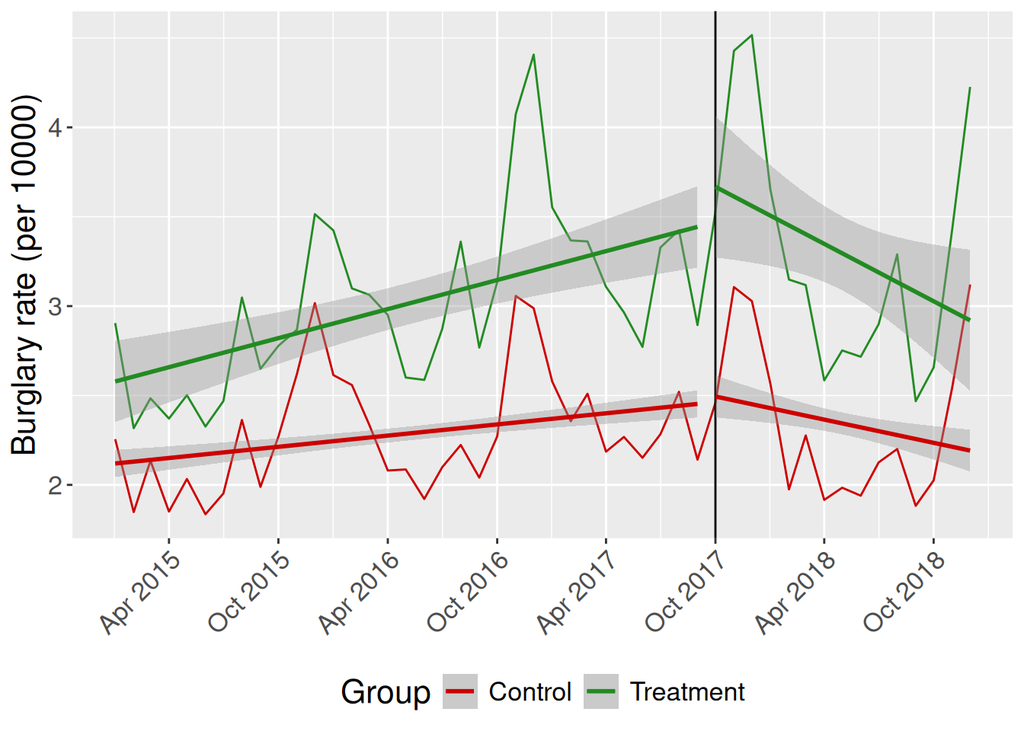

```r
ggplot(df_gendarmerie, aes(y = burglary_r, x = date, color = as.factor(dep_w), group = as.factor(dep_w))) +
  stat_summary(fun = "mean", geom = "line") +
  geom_vline(xintercept = as.numeric(as.Date("2017-10-01"))) +
  scale_x_date(date_breaks = "6 month", date_labels =  "%b %Y", limits = as.Date(c('2015-01-01','2018-12-01'))) +
  geom_smooth(aes(group = group), method = "lm", se = TRUE) +
  theme(axis.text.x=element_text(angle=45, hjust=1), legend.position = "bottom", text = element_text(size = 16)) +
  labs(colour = "Group", y = "Burglary rate (per 10000)", x = NULL) +
  scale_color_manual(values=c('red3','forestgreen'), labels=c("Control", "Treatment")) +
  scale_y_continuous()
```

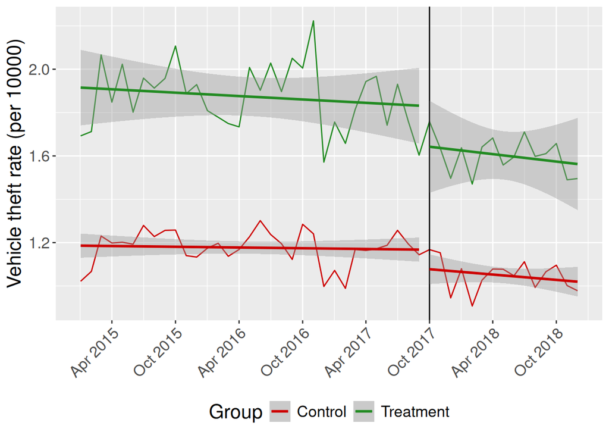

```r
ggsave("../output/counterfactual_gendarmerie_burglary_r.pdf", width = 2700, height = 1800, units = "px")

# vehicle theft

ggplot(df_gendarmerie, aes(y = vehicle_theft_r, x = date, color = as.factor(dep_w), group = as.factor(dep_w))) +
  stat_summary(fun = "mean", geom = "line") +
  geom_vline(xintercept = as.numeric(as.Date("2017-10-01"))) +
  scale_x_date(date_breaks = "6 month", date_labels =  "%b %Y", limits = as.Date(c('2015-01-01','2018-12-01'))) +
  geom_smooth(aes(group = group), method = "lm", se = TRUE) +
  theme(axis.text.x=element_text(angle=45, hjust=1), legend.position = "bottom", text = element_text(size = 16)) +
  labs(colour = "Group", y = "Vehicle theft rate (per 10000)", x = NULL) +
  scale_color_manual(values=c('red3','forestgreen'), labels=c("Control", "Treatment")) +
  scale_y_continuous()
```

```r
ggsave("../output/counterfactual_gendarmerie_vehicle_theft_r.pdf", width = 2700, height = 1800, units = "px")
```

### Regression

Models from this section are refered as “cg_” ( counterfactual gendarmerie)

First, create a fixed effect as interaction of treatment and period, for trend correction

```r
df_gendarmerie$trend_correction_treat <- ifelse(df_gendarmerie$dep_w == 1, df_gendarmerie$period, 0)


df_gendarmerie$trend_correction_control <- ifelse(df_gendarmerie$dep_w == 0, df_gendarmerie$period, 0)
```

#### Burglary

```r
cg_burglary1 <- feols(burglary_r ~ post + treat + dep_n + post:treat + dep_n:post, df_gendarmerie, cluster = 'jurisdiction_department')
cg_burglary2 <- feols(burglary_r ~ post + treat + dep_n + post:treat + dep_n:post | jurisdiction_department + date, df_gendarmerie, cluster = 'jurisdiction_department')
cg_burglary3 <- feols(burglary_r ~ post + treat + dep_n + post:treat + dep_n:post | department_month, df_gendarmerie, cluster = 'jurisdiction_department')
cg_burglary4 <- feols(burglary_r ~ post + treat + dep_n + post:treat + dep_n:post | jurisdiction_department + date + department_month, df_gendarmerie, cluster = 'jurisdiction_department')

etable(cg_burglary1, cg_burglary2, cg_burglary3, cg_burglary4)
```

```
##                              cg_burglary1     cg_burglary2     cg_burglary3
## Dependent Var.:                burglary_r       burglary_r       burglary_r
##
## Constant                2.146*** (0.0924)
## post                      0.0257 (0.0518)                  -0.0753 (0.0523)
## treat                   0.8643** (0.2699)
## dep_n                    0.2981. (0.1633)
## post x treat             0.2576. (0.1508) 0.2576. (0.1516)  0.2117 (0.1649)
## post x dep_n              0.0671 (0.0853)  0.0671 (0.0858)  0.0240 (0.0824)
## Fixed-Effects:          ----------------- ---------------- ----------------
## jurisdiction_department                No              Yes               No
## date                                   No              Yes               No
## department_month                       No               No              Yes
## _______________________ _________________ ________________ ________________
## S.E.: Clustered         by: jurisdictio.. by: jurisdicti.. by: jurisdicti..
## Observations                        4,416            4,416            4,416
## R2                                0.07562          0.61353          0.73325
## Within R2                              --          0.00291          0.00373
##
##                            cg_burglary4
## Dependent Var.:              burglary_r
##
## Constant
## post
## treat
## dep_n
## post x treat            0.2117 (0.1918)
## post x dep_n            0.0240 (0.0958)
## Fixed-Effects:          ---------------
## jurisdiction_department             Yes
## date                                Yes
## department_month                    Yes
## _______________________ _______________
## S.E.: Clustered         by: jurisdict..
## Observations                      4,416
## R2                              0.75630
## Within R2                       0.00298
## ---
## Signif. codes: 0 '***' 0.001 '**' 0.01 '*' 0.05 '.' 0.1 ' ' 1
```

```r
file_path <- "../output/tables/conterfact_gendarmerie_catchment_burglary.tex"
sink(file_path)
etable(cg_burglary1, cg_burglary2, cg_burglary3, cg_burglary4, tex = T)
sink()

# Power

se_tau_cg_burglary4 <- se(cg_burglary4)["post:treat"]
coeff_tau_cg_burglary4 <- coef(cg_burglary4)["post:treat"]

paste0("The power of our test of the treatment parameters is ", power.twoside(coeff_tau_cg_burglary4, 0.05, se_tau_cg_burglary4), " which means we have a ", power.twoside(coeff_tau_cg_burglary4, 0.05, se_tau_cg_burglary4), " probability of detecting such effect if it was the true effect")
```

```
## [1] "The power of our test of the treatment parameters is 0.197132132124269 which means we have a 0.197132132124269 probability of detecting such effect if it was the true effect"
```

Event study plot

```r
cg_burglary1_es <- feols(
  burglary_r ~  i(date, treat, ref = as.Date("2017-09-01")) | date + jurisdiction_department,
  data = subset(df_gendarmerie, dep_n == 0),
  cluster = ~ jurisdiction_department
)

summary(cg_burglary1_es)
```

```
## OLS estimation, Dep. Var.: burglary_r
## Observations: 2,592
## Fixed-effects: date: 48,  jurisdiction_department: 54
## Standard-errors: Clustered (jurisdiction_department)
##                         Estimate Std. Error   t value Pr(>|t|)
## date::2015-01-01:treat -0.080563   0.323634 -0.248932 0.804376
## date::2015-02-01:treat -0.342894   0.271975 -1.260754 0.212919
## date::2015-03-01:treat -0.522745   0.340091 -1.537073 0.130225
## date::2015-04-01:treat -0.359185   0.304708 -1.178785 0.243749
## date::2015-05-01:treat -0.379298   0.303244 -1.250803 0.216500
## date::2015-06-01:treat -0.357511   0.239047 -1.495571 0.140697
## date::2015-07-01:treat -0.218889   0.229075 -0.955533 0.343646
## date::2015-08-01:treat -0.218532   0.204745 -1.067337 0.290657
## date::2015-09-01:treat -0.144682   0.280800 -0.515251 0.608520
## date::2015-10-01:treat -0.272641   0.286463 -0.951749 0.345545
## date::2015-11-01:treat -0.594827   0.362402 -1.641348 0.106647
## date::2015-12-01:treat -0.252793   0.395279 -0.639531 0.525233
## date::2016-01-01:treat  0.024216   0.302520  0.080047 0.936501
## date::2016-02-01:treat -0.102185   0.252660 -0.404436 0.687520
## date::2016-03-01:treat  0.034478   0.230045  0.149874 0.881433
## date::2016-04-01:treat  0.153552   0.300473  0.511035 0.611449
## date::2016-05-01:treat -0.308953   0.213550 -1.446750 0.153856
## date::2016-06-01:treat -0.112498   0.266202 -0.422606 0.674293
## date::2016-07-01:treat -0.025397   0.213696 -0.118845 0.905847
## date::2016-08-01:treat  0.382435   0.225014  1.699608 0.095067 .
## date::2016-09-01:treat  0.057975   0.163382  0.354842 0.724116
## date::2016-10-01:treat  0.160251   0.228544  0.701183 0.486256
## date::2016-11-01:treat  0.269943   0.378461  0.713265 0.478811
## date::2016-12-01:treat  0.805870   0.338205  2.382788 0.020800 *
## date::2017-01-01:treat  0.309371   0.205047  1.508783 0.137293
## date::2017-02-01:treat  0.296473   0.263037  1.127119 0.264769
## date::2017-03-01:treat  0.211565   0.212629  0.995000 0.324257
## date::2017-04-01:treat  0.064513   0.401679  0.160608 0.873013
## date::2017-05-01:treat -0.193973   0.280483 -0.691568 0.492227
## date::2017-06-01:treat -0.225013   0.283302 -0.794254 0.430590
## date::2017-07-01:treat  0.169066   0.187481  0.901774 0.371257
## date::2017-08-01:treat  0.084527   0.193367  0.437132 0.663791
## date::2017-10-01:treat  0.389018   0.283506  1.372171 0.175790
## date::2017-11-01:treat  0.718822   0.463631  1.550418 0.126993
## date::2017-12-01:treat  0.959914   0.409552  2.343816 0.022870 *
## date::2018-01-01:treat  0.462952   0.274744  1.685030 0.097863 .
## date::2018-02-01:treat  0.495881   0.253518  1.955995 0.055745 .
## date::2018-03-01:treat  0.037818   0.249931  0.151313 0.880303
## date::2018-04-01:treat -0.171635   0.341972 -0.501899 0.617818
## date::2018-05-01:treat  0.046395   0.292139  0.158810 0.874422
## date::2018-06-01:treat -0.100984   0.266090 -0.379511 0.705824
## date::2018-07-01:treat -0.130908   0.255178 -0.513006 0.610079
## date::2018-08-01:treat  0.146371   0.389595  0.375702 0.708638
## date::2018-09-01:treat -0.294258   0.285614 -1.030266 0.307564
## date::2018-10-01:treat -0.148055   0.240530 -0.615537 0.540834
## date::2018-11-01:treat  0.202896   0.266201  0.762188 0.449326
## date::2018-12-01:treat  0.482556   0.312980  1.541809 0.129070
## ---
## Signif. codes:  0 '***' 0.001 '**' 0.01 '*' 0.05 '.' 0.1 ' ' 1
## RMSE: 0.650971     Adj. R2: 0.603558
##                  Within R2: 0.04039
```

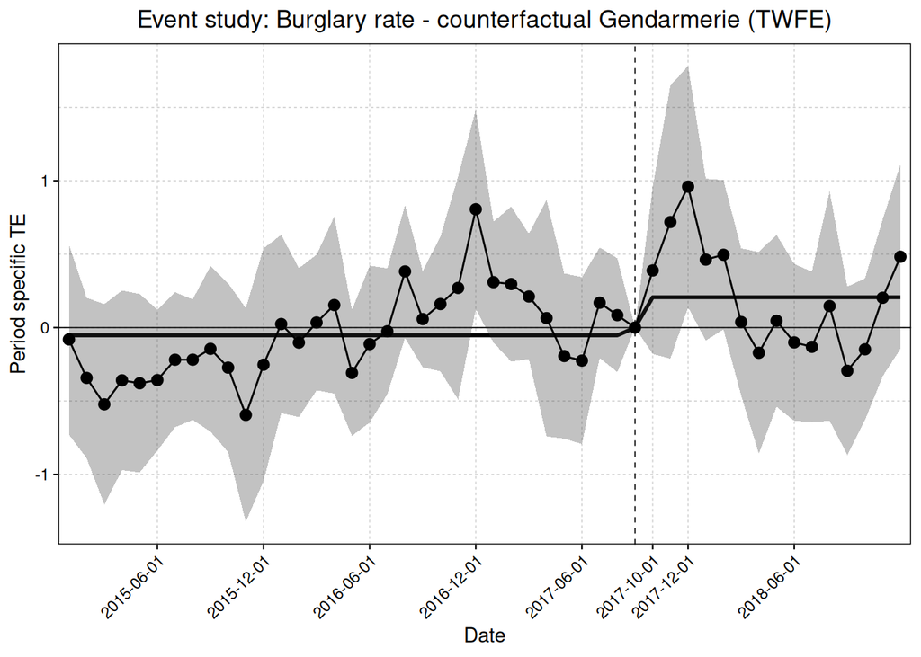

```r
# Plot

keep <- c("2017-10-01", "2015-06-01", "2015-12-01", "2016-06-01", "2016-12-01", "2017-06-01", "2017-12-01", "2018-06-01")

ggiplot(cg_burglary1_es, aggr_eff = "both", aggr_eff.par = list(col = "black"), geom_style = 'ribbon') +
  aes(group = 2) +
  scale_x_discrete(limits = as.character(all_dates), breaks = keep) +
  theme(axis.text.x = element_text(angle = 45, hjust = 1), line = element_line(linewidth = 0.8)) +
  labs(
    title = "Event study: Burglary rate - counterfactual Gendarmerie (TWFE)",
    x = "Date",
    y = "Period specific TE"
  )
```

```r
#

pdf("../output/event_study_conterfact_gendarmerie_burglary_r.pdf", width = 14, height = 8)
ggiplot(cg_burglary1_es, aggr_eff = "both", aggr_eff.par = list(col = "black"), geom_style = 'ribbon') +
  aes(group = 2) +
  scale_x_discrete(limits = as.character(all_dates), breaks = keep) +
  theme(axis.text.x = element_text(angle = 45, hjust = 1), line = element_line(linewidth = 0.4)) +
  labs(
    title = "Event study: Burglary rate - counterfactual Gendarmerie (TWFE)",
    x = "Date",
    y = "Period specific TE"
  )
dev.off()
```

#### Vehicle theft

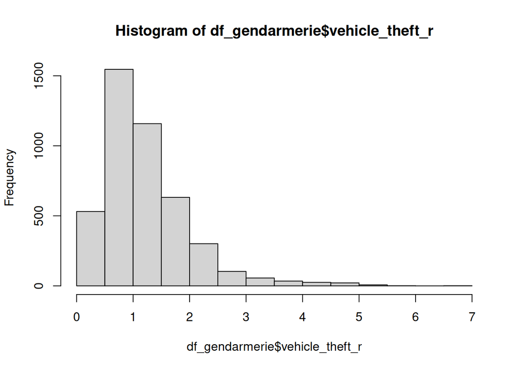

```r
hist(df_gendarmerie$vehicle_theft_r)
```

```r
#

cg_vehicle_theft1 <- feols(vehicle_theft_r ~ post + treat + dep_n + post:treat + dep_n:post, df_gendarmerie, cluster = 'jurisdiction_department')
cg_vehicle_theft2 <- feols(vehicle_theft_r ~ post + treat + dep_n + post:treat + dep_n:post | jurisdiction_department + date, df_gendarmerie, cluster = 'jurisdiction_department')
cg_vehicle_theft3 <- feols(vehicle_theft_r ~ post + treat + dep_n + post:treat + dep_n:post | department_month, df_gendarmerie, cluster = 'jurisdiction_department')
cg_vehicle_theft4 <- feols(vehicle_theft_r ~ post + treat + dep_n + post:treat + dep_n:post | jurisdiction_department + date + department_month, df_gendarmerie, cluster = 'jurisdiction_department')

etable(cg_vehicle_theft1, cg_vehicle_theft2, cg_vehicle_theft3, cg_vehicle_theft4)
```

```
##                          cg_vehicle_theft1 cg_vehicle_theft2  cg_vehicle_theft3
## Dependent Var.:            vehicle_theft_r   vehicle_theft_r    vehicle_theft_r
##
## Constant                 1.102*** (0.0880)
## post                    -0.1262** (0.0419)                   -0.1239** (0.0443)
## treat                    0.7718** (0.2537)
## dep_n                      0.1600 (0.1522)
## post x treat             -0.1450. (0.0818) -0.1450. (0.0822)  -0.1575. (0.0859)
## post x dep_n              -0.0046 (0.0495)  -0.0046 (0.0497)   -0.0118 (0.0522)
## Fixed-Effects:          ------------------ ----------------- ------------------
## jurisdiction_department                 No               Yes                 No
## date                                    No               Yes                 No
## department_month                        No                No                Yes
## _______________________ __________________ _________________ __________________
## S.E.: Clustered         by: jurisdiction.. by: jurisdictio.. by: jurisdiction..
## Observations                         4,416             4,416              4,416
## R2                                 0.09458           0.81624            0.86506
## Within R2                               --           0.00429            0.05878
##
##                         cg_vehicle_th..4
## Dependent Var.:          vehicle_theft_r
##
## Constant
## post
## treat
## dep_n
## post x treat            -0.1575 (0.0999)
## post x dep_n            -0.0118 (0.0607)
## Fixed-Effects:          ----------------
## jurisdiction_department              Yes
## date                                 Yes
## department_month                     Yes
## _______________________ ________________
## S.E.: Clustered         by: jurisdicti..
## Observations                       4,416
## R2                               0.86931
## Within R2                        0.00650
## ---
## Signif. codes: 0 '***' 0.001 '**' 0.01 '*' 0.05 '.' 0.1 ' ' 1
```

```r
file_path <- "../output/tables/conterfact_gendarmerie_catchment_vehicle.tex"
sink(file_path)
etable(cg_vehicle_theft1, cg_vehicle_theft2, cg_vehicle_theft3, cg_vehicle_theft4, tex = T)
sink()

# Power

se_tau_cg_vehicle_theft4 <- se(cg_vehicle_theft4)["post:treat"]
coeff_tau_cg_vehicle_theft4 <- coef(cg_vehicle_theft4)["post:treat"]

paste0("The power of our test of the treatment parameters is ", power.twoside(coeff_tau_cg_vehicle_theft4, 0.05, se_tau_cg_vehicle_theft4), " which means we have a ", power.twoside(coeff_tau_cg_vehicle_theft4, 0.05, se_tau_cg_vehicle_theft4), " probability of detecting such effect if it was the true effect")
```

```
## [1] "The power of our test of the treatment parameters is 0.351032387991452 which means we have a 0.351032387991452 probability of detecting such effect if it was the true effect"
```

Event study plot

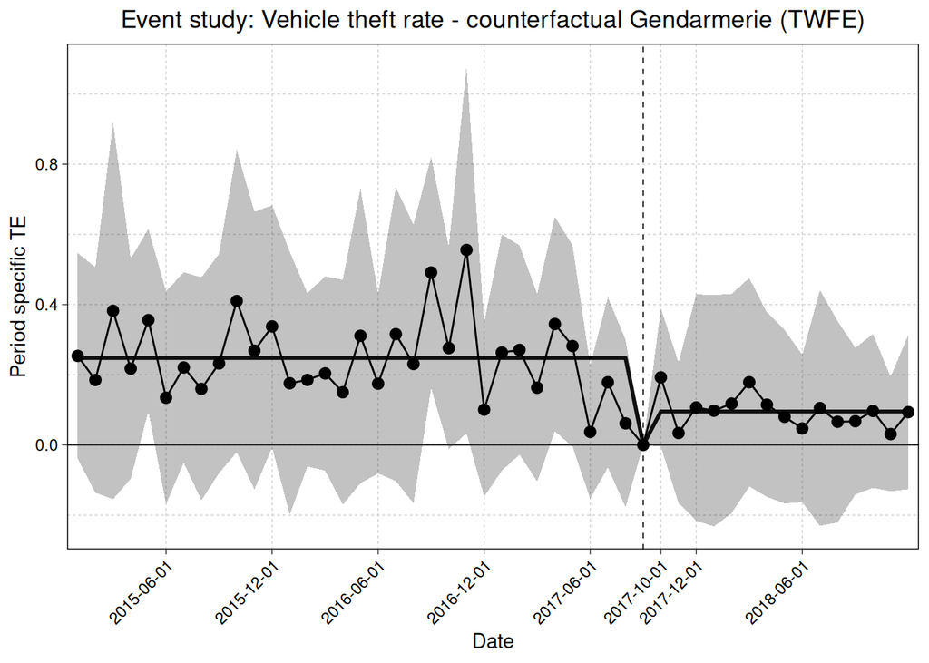

```r
# vehicle theft

cg_vehicle_theft1_es <- feols(vehicle_theft_r ~ i(as.factor(date),treat, ref = "2017-09-01") | jurisdiction_department + date, subset(df_gendarmerie, subset = dep_n == 0), cluster = 'jurisdiction_department')


ggiplot(cg_vehicle_theft1_es, aggr_eff = "both", aggr_eff.par = list(col = "black"), geom_style = 'ribbon') +
  aes(group = 1) +
  scale_x_discrete(limits = as.character(all_dates), breaks = keep) +
  theme(axis.text.x = element_text(angle = 45, hjust = 1), line = element_line(linewidth = 0.4)) +
  labs(
    title = "Event study: Vehicle theft rate - counterfactual Gendarmerie (TWFE)",
    x = "Date",
    y = "Period specific TE"
  )
```

```r
#
pdf("../output/event_study_conterfact_gendarmerie_vehicle_r.pdf", width = 14, height = 8)
ggiplot(cg_vehicle_theft1_es, aggr_eff = "both", aggr_eff.par = list(col = "black"), geom_style = 'ribbon') +
  aes(group = 1) +
  scale_x_discrete(limits = as.character(all_dates), breaks = keep) +
  theme(axis.text.x = element_text(angle = 45, hjust = 1), line = element_line(linewidth = 0.4)) +
  labs(
    title = "Event study: Vehicle theft rate - counterfactual Gendarmerie (TWFE)",
    x = "Date",
    y = "Period specific TE"
  )
dev.off()
```

## Estimation: comparing gendarmerie with police areas

Here the notation are a little bit more tricky: the treatment indicators is the jurisdiction, as we are working within treated department, but only the gendarmerie received PAVED in these departments.

### Plot

[figure not shown]

```r
ggplot(df_gendarmerie_police, aes(y = burglary_r, x = date, color = factor(jurisdiction), group = factor(jurisdiction))) +
  stat_summary(fun = "mean", geom = "line") +
  geom_vline(xintercept = as.numeric(as.Date("2017-10-01"))) +
  scale_x_date(date_breaks = "6 month", date_labels =  "%b %Y", limits = as.Date(c('2015-01-01','2018-12-01'))) +
  geom_smooth(aes(group = group), method = "lm", se = TRUE) +
  theme(axis.text.x=element_text(angle=45, hjust=1), legend.position = "bottom", text = element_text(size = 16)) +
  labs(colour = "Group", y = "Burglary rate (per 10000)", x = NULL) +
  scale_color_manual(values=c('red3', 'forestgreen'), labels = c("Police", "Gendarmerie")) +
  scale_y_continuous()
```

[figure not shown]

```r
ggsave("../output/counterfactual_police_burglary_r.pdf", width = 2700, height = 1800, units = "px")

# vehicle theft

ggplot(df_gendarmerie_police, aes(y = vehicle_theft_r, x = date, color = factor(jurisdiction), group = factor(jurisdiction))) +
  stat_summary(fun = "mean", geom = "line") +
  geom_vline(xintercept = as.numeric(as.Date("2017-10-01"))) +
  scale_x_date(date_breaks = "6 month", date_labels =  "%b %Y", limits = as.Date(c('2015-01-01','2018-12-01'))) +
  geom_smooth(aes(group = group), method = "lm", se = TRUE) +
  theme(axis.text.x=element_text(angle=45, hjust=1), legend.position = "bottom", text = element_text(size = 16)) +
  labs(colour = "Group", y = "Vehicle theft rate (per 10000)", x = NULL) +
  scale_color_manual(values=c('red3','forestgreen'), labels = c("Police", "Gendarmerie")) +
  scale_y_continuous()
```

```r
ggsave("../output/counterfactual_police_vehicle_theft_r.pdf", width = 2700, height = 1800, units = "px")
```

### Regression

The model from this section are refered as “gp_” (gendarmerie and police comparison). First we start by relevel jurisdiction for pn to be the reference:

```r
df_gendarmerie_police$jurisdiction <- as.factor(df_gendarmerie_police$jurisdiction)
df_gendarmerie_police$jurisdiction <- relevel(df_gendarmerie_police$jurisdiction, "pn")
```

#### Burglary

```r
gp_burglary1 <- feols(burglary_r ~ post + jurisdiction + post:jurisdiction, df_gendarmerie_police, cluster = 'jurisdiction_department')
gp_burglary2 <- feols(burglary_r ~ post + jurisdiction + post:jurisdiction | jurisdiction_department + date, df_gendarmerie_police, cluster = 'jurisdiction_department')
gp_burglary3 <- feols(burglary_r ~ post + jurisdiction + post:jurisdiction | department_month, df_gendarmerie_police, cluster = 'jurisdiction_department')
gp_burglary4 <- feols(burglary_r ~ post + jurisdiction + post:jurisdiction | jurisdiction_department + date + department_month, df_gendarmerie_police, cluster = 'jurisdiction_department')

etable(gp_burglary1, gp_burglary2, gp_burglary3, gp_burglary4)
```

```
##                              gp_burglary1     gp_burglary2       gp_burglary3
## Dependent Var.:                burglary_r       burglary_r         burglary_r
##
## Constant                4.432*** (0.5855)
## post                     -0.2383 (0.2587)                    -0.3854 (0.2856)
## jurisdictiongn           -1.422* (0.6400)                  -1.422*** (0.3634)
## post x jurisdictiongn    0.5216. (0.2962) 0.5216. (0.3028)    0.5216 (0.3204)
## Fixed-Effects:          ----------------- ---------------- ------------------
## jurisdiction_department                No              Yes                 No
## date                                   No              Yes                 No
## department_month                       No               No                Yes
## _______________________ _________________ ________________ __________________
## S.E.: Clustered         by: jurisdictio.. by: jurisdicti.. by: jurisdiction..
## Observations                        1,056            1,056              1,056
## R2                                0.13463          0.79899            0.65769
## Within R2                              --          0.02327            0.28377
##
##                            gp_burglary4
## Dependent Var.:              burglary_r
##
## Constant
## post
## jurisdictiongn
## post x jurisdictiongn   0.5216 (0.3285)
## Fixed-Effects:          ---------------
## jurisdiction_department             Yes
## date                                Yes
## department_month                    Yes
## _______________________ _______________
## S.E.: Clustered         by: jurisdict..
## Observations                      1,056
## R2                              0.83284
## Within R2                       0.02786
## ---
## Signif. codes: 0 '***' 0.001 '**' 0.01 '*' 0.05 '.' 0.1 ' ' 1
```

```r
file_path <- "../output/tables/conterfact_police_no_catchment_burglary.tex"
sink(file_path)
etable(gp_burglary1, gp_burglary2, gp_burglary3, gp_burglary4, tex = T)
sink()
```

Event study

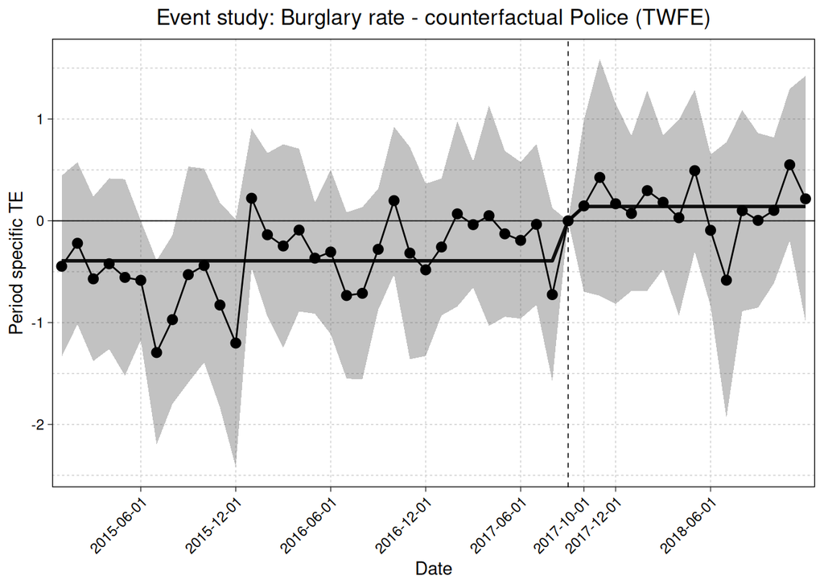

```r
df_gendarmerie_police$jurisdiction_gn <- ifelse(df_gendarmerie_police$jurisdiction == "gn", 1, 0)
df_gendarmerie_police$date <- as.Date(df_gendarmerie_police$date)

#

gp_burglary1_es <- feols(burglary_r ~ i(date, jurisdiction_gn, ref = as.Date("2017-09-01")) | jurisdiction_department + date, df_gendarmerie_police, cluster = 'jurisdiction_department')

#

ggiplot(gp_burglary1_es, aggr_eff = "both", aggr_eff.par = list(col = "black"), geom_style = 'ribbon') +
  aes(group = 1) +
  scale_x_discrete(limits = as.character(all_dates), breaks = keep) +
  theme(axis.text.x = element_text(angle = 45, hjust = 1), line = element_line(linewidth = 0.4)) +
  labs(
    title = "Event study: Burglary rate - counterfactual Police (TWFE)",
    x = "Date",
    y = "Period specific TE"
  )
```

```r
# ggfixest

pdf("../output/event_study_conterfact_police_burglary_r.pdf", width = 14, height = 8)
ggiplot(gp_burglary1_es, aggr_eff = "both", aggr_eff.par = list(col = "black"), geom_style = 'ribbon') +
  aes(group = 1) +
  scale_x_discrete(limits = as.character(all_dates), breaks = keep) +
  theme(axis.text.x = element_text(angle = 45, hjust = 1), line = element_line(linewidth = 0.4)) +
  labs(
    title = "Event study: Burglary rate - counterfactual Police (TWFE)",
    x = "Date",
    y = "Period specific TE"
  )
dev.off()
```

#### Vehicle theft

```r
gp_vehicle_theft1 <- feols(vehicle_theft_r ~ post + jurisdiction + post:jurisdiction, df_gendarmerie_police, cluster = 'jurisdiction_department')
gp_vehicle_theft2 <- feols(vehicle_theft_r ~ post + jurisdiction + post:jurisdiction | jurisdiction_department + date, df_gendarmerie_police, cluster = 'jurisdiction_department')
gp_vehicle_theft3 <- feols(vehicle_theft_r ~ post + jurisdiction + post:jurisdiction | department_month, df_gendarmerie_police, cluster = 'jurisdiction_department')
gp_vehicle_theft4 <- feols(vehicle_theft_r ~ post + jurisdiction + post:jurisdiction | jurisdiction_department + date + department_month, df_gendarmerie_police, cluster = 'jurisdiction_department')

etable(gp_vehicle_theft1, gp_vehicle_theft1, gp_vehicle_theft3, gp_vehicle_theft4)
```

```
##                           gp_vehicle_theft1 gp_vehicle_theft1.1
## Dependent Var.:             vehicle_theft_r     vehicle_theft_r
##
## Constant                  3.007*** (0.2462)   3.007*** (0.2462)
## post                    -0.4922*** (0.0827) -0.4922*** (0.0827)
## jurisdictiongn            -1.133** (0.3455)   -1.133** (0.3455)
## post x jurisdictiongn      0.2211. (0.1093)    0.2211. (0.1093)
## Fixed-Effects:          ------------------- -------------------
## department_month                         No                  No
## jurisdiction_department                  No                  No
## date                                     No                  No
## _______________________ ___________________ ___________________
## S.E.: Clustered         by: jurisdiction_.. by: jurisdiction_..
## Observations                          1,056               1,056
## R2                                  0.29400             0.29400
## Within R2                                --                  --
##
##                           gp_vehicle_theft3 gp_vehicle_th..4
## Dependent Var.:             vehicle_theft_r  vehicle_theft_r
##
## Constant
## post                    -0.5180*** (0.0921)
## jurisdictiongn           -1.133*** (0.1543)
## post x jurisdictiongn      0.2211. (0.1144) 0.2211. (0.1173)
## Fixed-Effects:          ------------------- ----------------
## department_month                        Yes              Yes
## jurisdiction_department                  No              Yes
## date                                     No              Yes
## _______________________ ___________________ ________________
## S.E.: Clustered         by: jurisdiction_.. by: jurisdicti..
## Observations                          1,056            1,056
## R2                                  0.77639          0.86484
## Within R2                           0.56988          0.01770
## ---
## Signif. codes: 0 '***' 0.001 '**' 0.01 '*' 0.05 '.' 0.1 ' ' 1
```

```r
file_path <- "../output/tables/conterfact_police_no_catchment_vehicle.tex"
sink(file_path)
etable(gp_vehicle_theft1, gp_vehicle_theft2, gp_vehicle_theft3, gp_vehicle_theft4, tex = T)
sink()
```

Event study plot

```r
gp_vehicle_theft1_es <- feols(vehicle_theft_r ~ i(date, jurisdiction_gn, ref = as.Date("2017-09-01")) | jurisdiction_department + date, df_gendarmerie_police, cluster = 'jurisdiction_department')

#

pdf("../output/event_study_conterfact_police_vehicle_r.pdf", width = 14, height = 8)
ggiplot(gp_vehicle_theft1_es, aggr_eff = "both", aggr_eff.par = list(col = "black"), geom_style = 'ribbon') +
  aes(group = 1) +
  scale_x_discrete(limits = as.character(all_dates), breaks = keep) +
  theme(axis.text.x = element_text(angle = 45, hjust = 1), line = element_line(linewidth = 0.4)) +
  labs(
    title = "Event study: Vehicle theft rate - counterfactual Police (TWFE)",
    x = "Date",
    y = "Period specific TE"
  )
dev.off()
```

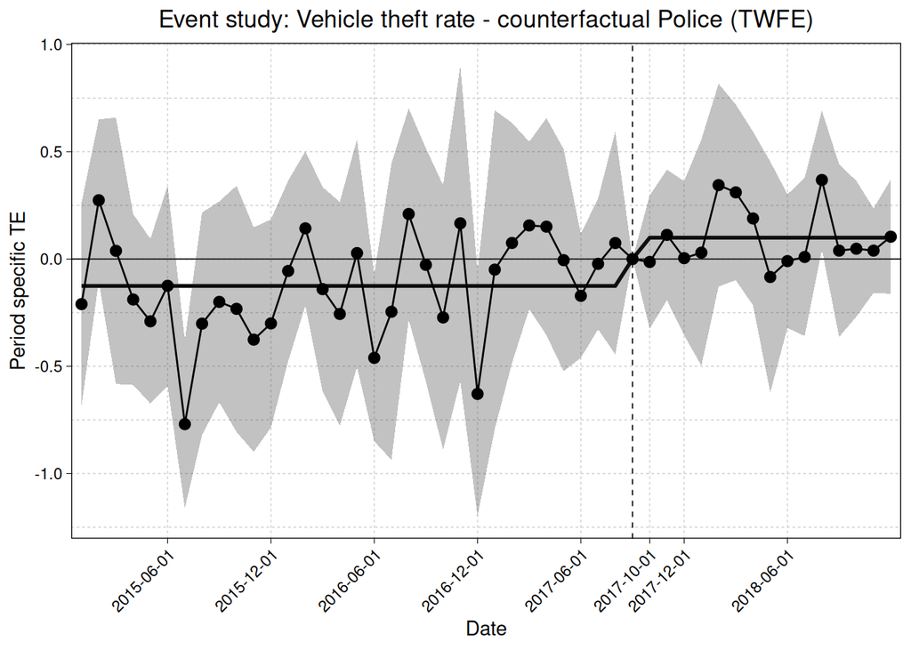

```r
ggiplot(gp_vehicle_theft1_es, aggr_eff = "both", aggr_eff.par = list(col = "black"), geom_style = 'ribbon') +
  aes(group = 1) +
  scale_x_discrete(limits = as.character(all_dates), breaks = keep) +
  theme(axis.text.x = element_text(angle = 45, hjust = 1), line = element_line(linewidth = 0.4)) +
  labs(
    title = "Event study: Vehicle theft rate - counterfactual Police (TWFE)",
    x = "Date",
    y = "Period specific TE"
  )
```

## Estimation: triple diff-in-diff

Here, we compare jurisdiction within a given department, and between control and treatment department

### Plot

We separate control (dep_w = 0) and treated department (dep_w = 1)

[figure not shown]

```r
df_didid$dep_w_plot <- ifelse(df_didid$dep_w == 1, "Treatment", "Control")

ggplot(df_didid, aes(y = burglary_r, x = date, color = factor(jurisdiction), group = factor(jurisdiction))) +
  stat_summary(fun = "mean", geom = "line") +
  geom_vline(xintercept = as.numeric(as.Date("2017-10-01"))) +
  scale_x_date(date_breaks = "6 month", date_labels =  "%b %Y", limits = as.Date(c('2015-01-01','2018-12-01'))) +
  geom_smooth(aes(group = group), method = "lm", se = TRUE) +
  theme(axis.text.x=element_text(angle=45, hjust=1), legend.position = "bottom", text = element_text(size = 16)) +
  labs(colour = "Group", y = "Burglary rate (per 10000)", x = NULL) +
  scale_color_manual(values=c('red3', 'forestgreen'), labels = c("Police", "Gendarmerie")) +
  scale_y_continuous() +
  facet_wrap(~ dep_w_plot, ncol = 1)
```

[figure not shown]

```r
ggsave("../output/counterfactual_didid_burglary_r.pdf", width = 2700, height = 2700, units = "px")

####

ggplot(df_didid, aes(y = vehicle_theft_r, x = date, color = factor(jurisdiction), group = factor(jurisdiction))) +
  stat_summary(fun = "mean", geom = "line") +
  geom_vline(xintercept = as.numeric(as.Date("2017-10-01"))) +
  scale_x_date(date_breaks = "6 month", date_labels =  "%b %Y", limits = as.Date(c('2015-01-01','2018-12-01'))) +
  geom_smooth(aes(group = group), method = "lm", se = TRUE) +
  theme(axis.text.x=element_text(angle=45, hjust=1), legend.position = "bottom", text = element_text(size = 16)) +
  labs(colour = "Group", y = "Vehicle theft rate (per 10000)", x = NULL) +
  scale_color_manual(values=c('red3', 'forestgreen'), labels = c("Police", "Gendarmerie")) +
  scale_y_continuous() +
  facet_wrap(~ dep_w_plot, ncol = 1)
```

```r
ggsave("../output/counterfactual_didid_vehicle_theft_r.pdf", width = 2700, height = 2700, units = "px")
```

### Regression

Models here are refered as “d3” (for triple diff)

```r
df_didid$jurisdiction <- as.factor(df_didid$jurisdiction)
df_didid$jurisdiction <- relevel(df_didid$jurisdiction, "pn")
```

#### Burglary

```r
cd3_burglary1 <- feols(burglary_r ~ post*dep_w*jurisdiction + post*dep_n, df_didid, cluster = 'jurisdiction_department')
cd3_burglary2 <- feols(burglary_r ~ post*dep_w*jurisdiction + post*dep_n | jurisdiction_department + date, df_didid, cluster = 'jurisdiction_department')
cd3_burglary3 <- feols(burglary_r ~ post*dep_w*jurisdiction + post*dep_n | department_month, df_didid, cluster = 'jurisdiction_department')
cd3_burglary4 <- feols(burglary_r ~ post*dep_w*jurisdiction + post*dep_n | jurisdiction_department + date + department_month, df_didid, cluster = 'jurisdiction_department')

etable(cd3_burglary1, cd3_burglary2, cd3_burglary3, cd3_burglary4)
```

```
##                                     cd3_burglary1    cd3_burglary2
## Dependent Var.:                        burglary_r       burglary_r
##
## Constant                        2.906*** (0.1427)
## post                              0.0134 (0.0717)
## dep_w                             1.526* (0.5906)
## jurisdictiongn                -0.9038*** (0.1801)
## dep_n                           0.6040** (0.1859)
## post x dep_w                     -0.2516 (0.2631) -0.2516 (0.2638)
## post x jurisdictiongn             0.0513 (0.0822)  0.0513 (0.0824)
## dep_w x jurisdictiongn           -0.5178 (0.6518)
## post x dep_n                     -0.0158 (0.0837) -0.0158 (0.0839)
## post x dep_w x jurisdictiongn     0.4704 (0.3014)  0.4704 (0.3021)
## Fixed-Effects:                ------------------- ----------------
## jurisdiction_department                        No              Yes
## date                                           No              Yes
## department_month                               No               No
## _____________________________ ___________________ ________________
## S.E.: Clustered               by: jurisdiction_.. by: jurisdicti..
## Observations                                8,832            8,832
## R2                                        0.15317          0.69557
## Within R2                                      --          0.00235
##
##                                     cd3_burglary3    cd3_burglary4
## Dependent Var.:                        burglary_r       burglary_r
##
## Constant
## post                             -0.0849 (0.0776)
## dep_w
## jurisdictiongn                -0.9038*** (0.0969)
## dep_n
## post x dep_w                     -0.3006 (0.2902) -0.3006 (0.2910)
## post x jurisdictiongn             0.0513 (0.0853)  0.0513 (0.0855)
## dep_w x jurisdictiongn           -0.5178 (0.3687)
## post x dep_n                     -0.0463 (0.0897) -0.0463 (0.0900)
## post x dep_w x jurisdictiongn     0.4704 (0.3250)  0.4704 (0.3259)
## Fixed-Effects:                ------------------- ----------------
## jurisdiction_department                        No              Yes
## date                                           No              Yes
## department_month                              Yes              Yes
## _____________________________ ___________________ ________________
## S.E.: Clustered               by: jurisdiction_.. by: jurisdicti..
## Observations                                8,832            8,832
## R2                                        0.61942          0.75360
## Within R2                                 0.18310          0.00309
## ---
## Signif. codes: 0 '***' 0.001 '**' 0.01 '*' 0.05 '.' 0.1 ' ' 1
```

```r
file_path <- "../output/tables/conterfact_d3_catchment_burglary.tex"
sink(file_path)
etable(cd3_burglary1, cd3_burglary2, cd3_burglary3, cd3_burglary4, tex = T)
sink()
```

Event study plot

```r
df_didid$jurisdiction_gn <- ifelse(df_didid$jurisdiction == "gn", 1, 0)
df_didid$date <- as.Date(df_didid$date)


d3_burglary1_es <- feols(burglary_r ~ i(date, dep_w*jurisdiction_gn, ref = as.Date("2017-09-01")) | jurisdiction_department + date, df_didid, cluster = 'jurisdiction_department')

#

pdf("../output/event_study_conterfact_3d_burglary_r.pdf", width = 14, height = 8)
ggiplot(d3_burglary1_es, aggr_eff = "both", aggr_eff.par = list(col = "black"), geom_style = 'ribbon') +
  aes(group = 1) +
  scale_x_discrete(limits = as.character(all_dates), breaks = keep) +
  theme(axis.text.x = element_text(angle = 45, hjust = 1), line = element_line(linewidth = 0.4)) +
  labs(
    title = "Event study: Burglary rate - DiDiD counterfactual (TWFE)",
    x = "Date",
    y = "Period specific TE"
  )
dev.off()
```

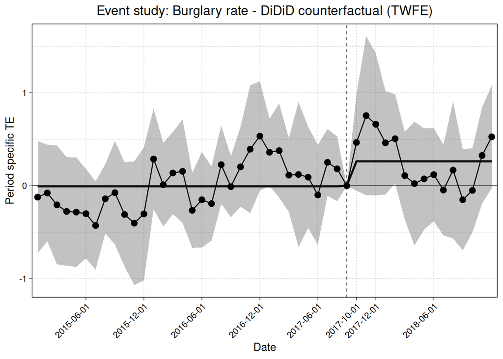

```r
ggiplot(d3_burglary1_es, aggr_eff = "both", aggr_eff.par = list(col = "black"), geom_style = 'ribbon') +
  aes(group = 1) +
  scale_x_discrete(limits = as.character(all_dates), breaks = keep) +
  theme(axis.text.x = element_text(angle = 45, hjust = 1), line = element_line(linewidth = 0.4)) +
  labs(
    title = "Event study: Burglary rate - DiDiD counterfactual (TWFE)",
    x = "Date",
    y = "Period specific TE"
  )
```

#### Vehicle theft

```r
cd3_vehicle_theft1 <- feols(vehicle_theft_r ~ post*dep_w*jurisdiction + post*dep_n, df_didid, cluster = 'jurisdiction_department')
cd3_vehicle_theft2 <- feols(vehicle_theft_r ~ post*dep_w*jurisdiction + post*dep_n | jurisdiction_department + date, df_didid, cluster = 'jurisdiction_department')
cd3_vehicle_theft3 <- feols(vehicle_theft_r ~ post*dep_w*jurisdiction + post*dep_n | department_month, df_didid, cluster = 'jurisdiction_department')
cd3_vehicle_theft4 <- feols(vehicle_theft_r ~ post*dep_w*jurisdiction + post*dep_n | jurisdiction_department + date + department_month, df_didid, cluster = 'jurisdiction_department')

etable(cd3_vehicle_theft1, cd3_vehicle_theft2, cd3_vehicle_theft3, cd3_vehicle_theft4)
```

```
##                                cd3_vehicle_theft1 cd3_vehicle_theft2
## Dependent Var.:                   vehicle_theft_r    vehicle_theft_r
##
## Constant                        2.126*** (0.1084)
## post                          -0.3577*** (0.0439)
## dep_w                           0.8808** (0.2642)
## jurisdictiongn                 -1.121*** (0.1715)
## dep_n                            0.3670* (0.1796)
## post x dep_w                     -0.1345 (0.0921)   -0.1345 (0.0923)
## post x jurisdictiongn          0.2484*** (0.0470) 0.2484*** (0.0471)
## dep_w x jurisdictiongn           -0.0119 (0.3792)
## post x dep_n                     -0.0407 (0.0468)   -0.0407 (0.0469)
## post x dep_w x jurisdictiongn    -0.0274 (0.1169)   -0.0274 (0.1172)
## Fixed-Effects:                ------------------- ------------------
## jurisdiction_department                        No                Yes
## date                                           No                Yes
## department_month                               No                 No
## _____________________________ ___________________ __________________
## S.E.: Clustered               by: jurisdiction_.. by: jurisdiction..
## Observations                                8,832              8,832
## R2                                        0.21864            0.84662
## Within R2                                      --            0.01415
##
##                                cd3_vehicle_theft3 cd3_vehicle_theft4
## Dependent Var.:                   vehicle_theft_r    vehicle_theft_r
##
## Constant
## post                          -0.3577*** (0.0487)
## dep_w
## jurisdictiongn                 -1.121*** (0.1031)
## dep_n
## post x dep_w                     -0.1604 (0.1024)   -0.1604 (0.1027)
## post x jurisdictiongn          0.2484*** (0.0504) 0.2484*** (0.0506)
## dep_w x jurisdictiongn           -0.0119 (0.1829)
## post x dep_n                     -0.0552 (0.0537)   -0.0552 (0.0538)
## post x dep_w x jurisdictiongn    -0.0274 (0.1228)   -0.0274 (0.1231)
## Fixed-Effects:                ------------------- ------------------
## jurisdiction_department                        No                Yes
## date                                           No                Yes
## department_month                              Yes                Yes
## _____________________________ ___________________ __________________
## S.E.: Clustered               by: jurisdiction_.. by: jurisdiction..
## Observations                                8,832              8,832
## R2                                        0.67538            0.86743
## Within R2                                 0.35006            0.01699
## ---
## Signif. codes: 0 '***' 0.001 '**' 0.01 '*' 0.05 '.' 0.1 ' ' 1
```

```r
file_path <- "../output/tables/conterfact_d3_catchment_vehicle.tex"
sink(file_path)
etable(cd3_vehicle_theft1, cd3_vehicle_theft2, cd3_vehicle_theft3, cd3_vehicle_theft4, tex = T)
sink()
```

Event study plot

```r
df_didid$jurisdiction_gn <- ifelse(df_didid$jurisdiction == "gn", 1, 0)

d3_vehicle_theft_1_es <- feols(vehicle_theft_r ~ i(date, dep_w*jurisdiction_gn, ref = as.Date("2017-09-01")) | jurisdiction_department + date, df_didid, cluster = 'jurisdiction_department')

#
pdf("../output/event_study_conterfact_3d_vehicle_r.pdf", width = 14, height = 8)
ggiplot(d3_vehicle_theft_1_es, aggr_eff = "both", aggr_eff.par = list(col = "black"), geom_style = 'ribbon') +
  aes(group = 1) +
  scale_x_discrete(limits = as.character(all_dates), breaks = keep) +
  theme(axis.text.x = element_text(angle = 45, hjust = 1), line = element_line(linewidth = 0.4)) +
  labs(
    title = "Event study: Vehicle theft rate - DiDiD counterfactual (TWFE)",
    x = "Date",
    y = "Period specific TE"
  )
dev.off()
```

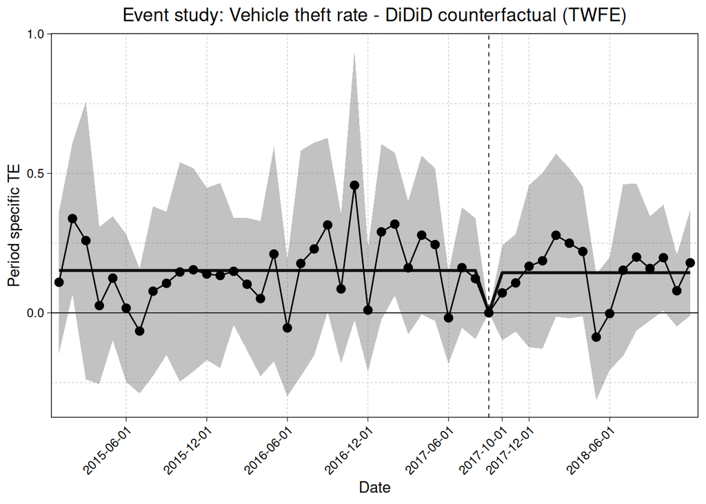

```r
ggiplot(d3_vehicle_theft_1_es, aggr_eff = "both", aggr_eff.par = list(col = "black"), geom_style = 'ribbon') +
  aes(group = 1) +
  scale_x_discrete(limits = as.character(all_dates), breaks = keep) +
  theme(axis.text.x = element_text(angle = 45, hjust = 1), line = element_line(linewidth = 0.4)) +
  labs(
    title = "Event study: Vehicle theft rate - DiDiD counterfactual (TWFE)",
    x = "Date",
    y = "Period specific TE"
  )
```

# Robustness check: Count regression

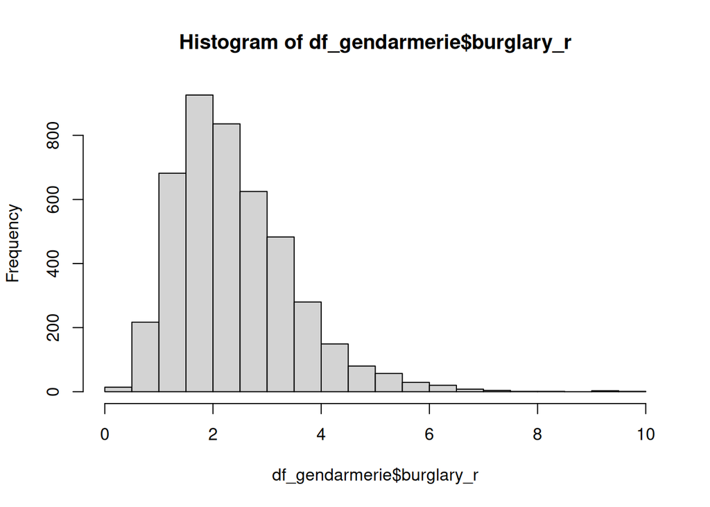

```r
hist(df_gendarmerie$burglary_r)
```

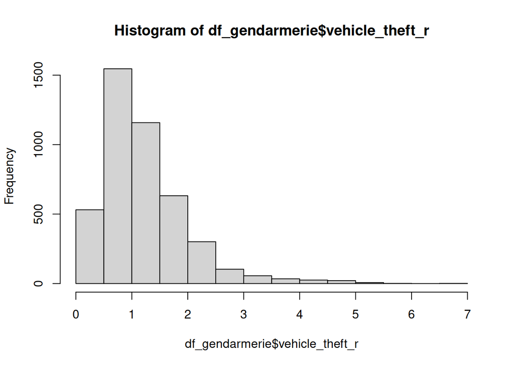

```r
hist(df_gendarmerie$vehicle_theft_r)
```

If we look at the histogram of the rate of burglary and vehicle theft, we can observe that the distributions are not standard distribution. Then, we estimate a count regressions to ensure that our results are not due to a wrong model choice.

GLM with count distribution use a log link function. Thus, we have to check the pre-trend with the log of the crime level.

### Plot

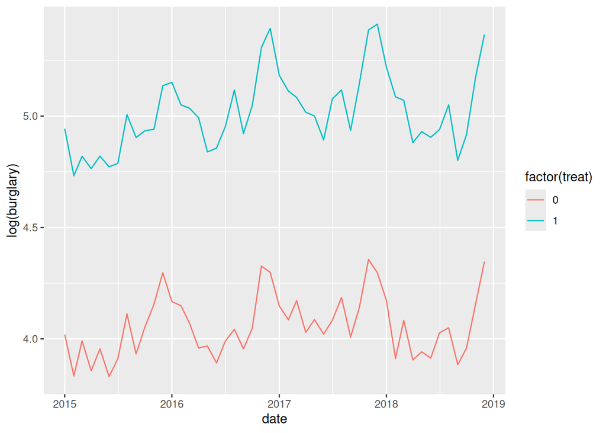

```r
ggplot(df_gendarmerie, aes(y = log(burglary), x = date, color = factor(treat), group = factor(treat))) +
  stat_summary(fun = "mean", geom = "line")
```

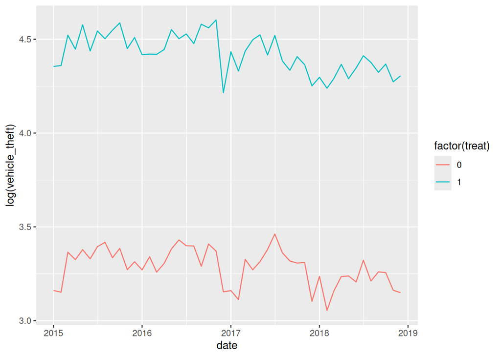

```r
ggplot(df_gendarmerie, aes(y = log(vehicle_theft), x = date, color = factor(treat), group = factor(treat))) +
  stat_summary(fun = "mean", geom = "line")
```

Still quite convincing, we can proceed to the regressions.

### Regression

Since we are interested in the rate of crime, we add the population as an offset in the specification.

But the question is: which kind of regression to use? Poisson regression needs the mean of the distribution to be roughly equal to the variance, which is clearly not the case as we have a strong overdispersion. Negative Binomial can be an alternative, but require the distribution to be exactly negative binomial, which is not the case. Quasi poisson regression can be an answer.

Both negative binomial and quasi poisson are made to model over-dispersed outcomes. However, the quasi poisson assumes that the variance of the model is linear to the mean, while the negative binomial assumes it is quadratic.

```r
g_poisson_burglary1 <- fenegbin(burglary ~ post + treat + post:treat, df_gendarmerie, cluster = 'jurisdiction_department', offset = ~log(population))
g_poisson_burglary2 <- fenegbin(burglary ~ post:treat | department + date, df_gendarmerie, cluster = 'jurisdiction_department', offset = ~log(population))
g_poisson_burglary3 <- fenegbin(burglary ~ post + post:treat | department_month, df_gendarmerie, cluster = 'jurisdiction_department', offset = ~log(population))
g_poisson_burglary4 <- fenegbin(burglary ~ post:treat | department + date + department_month, df_gendarmerie, cluster = 'jurisdiction_department', offset = ~log(population))

etable(g_poisson_burglary1, g_poisson_burglary2, g_poisson_burglary3, g_poisson_burglary4)
```

```
##                  g_poisson_burgl..1 g_poisson_bu..2 g_poisson_bur..3
## Dependent Var.:            burglary        burglary         burglary
##
## Constant         -8.380*** (0.0358)
## post                0.0270 (0.0178)                 -0.0177 (0.0163)
## treat             0.2718** (0.0926)
## post x treat        0.0615 (0.0475) 0.0558 (0.0406)  0.0497 (0.0437)
## Fixed-Effects:   ------------------ --------------- ----------------
## department                       No             Yes               No
## date                             No             Yes               No
## department_month                 No              No              Yes
## ________________ __________________ _______________ ________________
## S.E.: Clustered  by: jurisdiction.. by: jurisdict.. by: jurisdicti..
## Observations                  4,416           4,416            4,416
## Squared Cor.                0.60365         0.88166          0.92043
## Pseudo R2                   0.11331         0.20522          0.23507
## BIC                        42,355.7        39,110.4         45,792.9
## Over-dispersion              5.8774          19.250           30.283
##
##                  g_poisson_bu..4
## Dependent Var.:         burglary
##
## Constant
## post
## treat
## post x treat     0.0505 (0.0441)
## Fixed-Effects:   ---------------
## department                   Yes
## date                         Yes
## department_month             Yes
## ________________ _______________
## S.E.: Clustered  by: jurisdict..
## Observations               4,416
## Squared Cor.             0.92988
## Pseudo R2                0.24391
## BIC                     46,520.8
## Over-dispersion           35.089
## ---
## Signif. codes: 0 '***' 0.001 '**' 0.01 '*' 0.05 '.' 0.1 ' ' 1
```

```r
g_poisson_vehicle_theft1 <- feglm(vehicle_theft ~ post + treat + post:treat, df_gendarmerie, cluster = 'jurisdiction_department', family=quasipoisson, offset = log(df_gendarmerie$population))
g_poisson_vehicle_theft2 <- feglm(vehicle_theft ~ post:treat | department + date, df_gendarmerie, cluster = 'jurisdiction_department', family=quasipoisson, offset =log(df_gendarmerie$population))
g_poisson_vehicle_theft3 <- feglm(vehicle_theft ~ post:treat | department + date + department_month, df_gendarmerie, cluster = 'jurisdiction_department', family=quasipoisson, offset = log(df_gendarmerie$population))

g_poisson_vehicle_theft4 <- fenegbin(vehicle_theft ~ post:treat | department + date + department_month, df_gendarmerie, cluster = 'jurisdiction_department', offset = log(df_gendarmerie$population))

# results

etable(g_poisson_vehicle_theft1, g_poisson_vehicle_theft2, g_poisson_vehicle_theft3, g_poisson_vehicle_theft4)
```

```
##                  g_poisson_vehicl..1    g_poisson_veh..2    g_poisson_veh..3
## Dependent Var.:        vehicle_theft       vehicle_theft       vehicle_theft
##
## Constant          -9.015*** (0.0624)
## post             -0.1113*** (0.0198)
## treat              0.4103** (0.1460)
## post x treat        -0.0201 (0.0385)    -0.0180 (0.0385)    -0.0234 (0.0388)
## Fixed-Effects:   -------------------    ----------------    ----------------
## department                        No                 Yes                 Yes
## date                              No                 Yes                 Yes
## department_month                  No                  No                 Yes
## ________________ ___________________    ________________    ________________
## Family           quasipoisson("log") quasipoisson("log") quasipoisson("log")
## S.E.: Clustered  by: jurisdiction_..    by: jurisdicti..    by: jurisdicti..
## Observations                   4,416               4,416               4,416
## Squared Cor.                 0.55753             0.92835             0.95063
## Pseudo R2                         --                  --                  --
## BIC                               --                  --                  --
## Over-dispersion                   --                  --                  --
##
##                  g_poisson_veh..4
## Dependent Var.:     vehicle_theft
##
## Constant
## post
## treat
## post x treat     -0.0347 (0.0407)
## Fixed-Effects:   ----------------
## department                    Yes
## date                          Yes
## department_month              Yes
## ________________ ________________
## Family                  Neg. Bin.
## S.E.: Clustered  by: jurisdicti..
## Observations                4,416
## Squared Cor.              0.95013
## Pseudo R2                 0.30444
## BIC                      39,913.3
## Over-dispersion            88.999
## ---
## Signif. codes: 0 '***' 0.001 '**' 0.01 '*' 0.05 '.' 0.1 ' ' 1
```

# Review

## Effect in percentage

Run the final regressions with Poisson regression, offset for the population, and calculate the effect in percentage

```r
df_didid$jurisdiction <- as.factor(df_didid$jurisdiction)
df_didid$jurisdiction <- relevel(df_didid$jurisdiction, "pn")

df_gendarmerie_police$jurisdiction <- as.factor(df_gendarmerie_police$jurisdiction)

df_gendarmerie_police$jurisdiction <- relevel(df_gendarmerie_police$jurisdiction, "pn")

cg_burglary4_percentage <- fepois(burglary ~ post + treat + dep_n + post:treat + dep_n:post | jurisdiction_department + date + department_month, df_gendarmerie, cluster = 'jurisdiction_department', offset = log(df_gendarmerie$pop))

cg_vehicle_theft4_percentage <- fepois(vehicle_theft ~ post + treat + dep_n + post:treat + dep_n:post | jurisdiction_department + date + department_month, df_gendarmerie, cluster = 'jurisdiction_department', offset = log(df_gendarmerie$pop))

gp_burglary4_percentage <- fepois(burglary ~ post + jurisdiction + post:jurisdiction | jurisdiction_department + date + department_month, df_gendarmerie_police, cluster = 'jurisdiction_department', offset = log(df_gendarmerie_police$pop))

gp_vehicle_theft4_percentage <- fepois(vehicle_theft ~ post + jurisdiction + post:jurisdiction | jurisdiction_department + date + department_month, df_gendarmerie_police, cluster = 'jurisdiction_department', offset = log(df_gendarmerie_police$pop))

cd3_burglary4_percentage <- fepois(burglary ~ post*dep_w*jurisdiction + post*dep_n | jurisdiction_department + date + department_month, df_didid, cluster = 'jurisdiction_department', offset = log(df_didid$pop))

cd3_vehicle_theft4_percentage <- fepois(vehicle_theft ~ post*dep_w*jurisdiction + post*dep_n | jurisdiction_department + date + department_month, df_didid, cluster = 'jurisdiction_department', offset = log(df_didid$pop))

file_path <- "../output/tables/poisson_reg_model4.tex"
sink(file_path)
etable(cg_burglary4_percentage, cg_vehicle_theft4_percentage, gp_burglary4_percentage, gp_vehicle_theft4_percentage, cd3_burglary4_percentage, cd3_vehicle_theft4_percentage, tex = T)
sink()

etable(cg_burglary4_percentage, cg_vehicle_theft4_percentage, gp_burglary4_percentage, gp_vehicle_theft4_percentage, cd3_burglary4_percentage, cd3_vehicle_theft4_percentage)
```

```
##                               cg_burglary4_.. cg_vehicle_the.. gp_burglary4_p..
## Dependent Var.:                      burglary    vehicle_theft         burglary
##
## post x treat                  0.0387 (0.0655) -0.0243 (0.0592)
## post x dep_n                  0.0289 (0.0374) -0.0016 (0.0518)
## post x jurisdictiongn                                          0.1351. (0.0711)
## post x dep_w
## post x dep_w x jurisdictiongn
## Fixed-Effects:                --------------- ---------------- ----------------
## jurisdiction_department                   Yes              Yes              Yes
## date                                      Yes              Yes              Yes
## department_month                          Yes              Yes              Yes
## _____________________________ _______________ ________________ ________________
## S.E.: Clustered               by: jurisdict.. by: jurisdicti.. by: jurisdicti..
## Observations                            4,416            4,416            1,056
## Squared Cor.                          0.93120          0.95063          0.95735
## Pseudo R2                             0.83549          0.81466          0.90360
## BIC                                  51,768.0         40,473.2         14,255.2
##
##                               gp_vehicle_th.. cd3_burglary4_.. cd3_vehicle_th..
## Dependent Var.:                 vehicle_theft         burglary    vehicle_theft
##
## post x treat
## post x dep_n                                   0.0159 (0.0264)  0.0243 (0.0294)
## post x jurisdictiongn         0.0260 (0.0390) 0.0475. (0.0254) 0.0636* (0.0267)
## post x dep_w                                  -0.0612 (0.0521)  0.0275 (0.0313)
## post x dep_w x jurisdictiongn                  0.0882 (0.0726) -0.0377 (0.0459)
## Fixed-Effects:                --------------- ---------------- ----------------
## jurisdiction_department                   Yes              Yes              Yes
## date                                      Yes              Yes              Yes
## department_month                          Yes              Yes              Yes
## _____________________________ _______________ ________________ ________________
## S.E.: Clustered               by: jurisdict.. by: jurisdicti.. by: jurisdicti..
## Observations                            1,056            8,832            8,832
## Squared Cor.                          0.98067          0.96517          0.98676
## Pseudo R2                             0.90928          0.91041          0.91850
## BIC                                  10,312.4         96,320.3         73,856.5
## ---
## Signif. codes: 0 '***' 0.001 '**' 0.01 '*' 0.05 '.' 0.1 ' ' 1
```

```r
summary(df_gendarmerie$burglary_r)
```

```
##    Min. 1st Qu.  Median    Mean 3rd Qu.    Max.
##  0.2629  1.6035  2.2094  2.3989  3.0081  9.5489
```

```r
###

library(fixest)
library(dplyr)
library(tidyr)
library(ggplot2)
library(purrr)
library(broom)
library(xtable)

# Named mapping of models to the term to extract
coef_map <- c(
  cg_burglary4_percentage      = "post:treat",
  cg_vehicle_theft4_percentage = "post:treat ",
  gp_burglary4_percentage      = "post:jurisdictiongn",
  gp_vehicle_theft4_percentage = "post:jurisdictiongn",
  cd3_burglary4_percentage     = "post:dep_w:jurisdictiongn",
  cd3_vehicle_theft4_percentage= "post:dep_w:jurisdictiongn"
)

models <- list(
  cg_burglary4_percentage      = cg_burglary4_percentage,
  cg_vehicle_theft4_percentage = cg_vehicle_theft4_percentage,
  gp_burglary4_percentage      = gp_burglary4_percentage,
  gp_vehicle_theft4_percentage = gp_vehicle_theft4_percentage,
  cd3_burglary4_percentage     = cd3_burglary4_percentage,
  cd3_vehicle_theft4_percentage= cd3_vehicle_theft4_percentage
)
# Function to extract stats from a fixest poisson model
extract_info <- function(model_name, model_obj) {

  est <- broom::tidy(model_obj, conf.int = TRUE)

  est %>%
    mutate(
      model = model_name,

      # IRR and CI
      IRR = exp(estimate),
      IRR_low = exp(conf.low),
      IRR_high = exp(conf.high),

      # Percent effects
      pct =  (IRR - 1) * 100,
      pct_low = (IRR_low - 1) * 100,
      pct_high = (IRR_high - 1) * 100
    ) %>%
    select(
      model, term, estimate, IRR,  std.error,
      pct, pct_low, pct_high
    )
}

# Build full table
results_table <- as.data.frame(map2_df(names(models), models, extract_info))
results_table <- cbind(subset(results_table, select = c(model, term)),  apply(subset(results_table, select = -c(model, term)), 2, as.numeric))
results_table <- cbind(subset(results_table, select = c(model, term)),  apply(subset(results_table, select = -c(model, term)), 2, function(x) round(x, 2)))

results_table
```

```
##                            model                      term estimate  IRR
## 1        cg_burglary4_percentage                post:treat     0.04 1.04
## 2        cg_burglary4_percentage                post:dep_n     0.03 1.03
## 3   cg_vehicle_theft4_percentage                post:treat    -0.02 0.98
## 4   cg_vehicle_theft4_percentage                post:dep_n     0.00 1.00
## 5        gp_burglary4_percentage       post:jurisdictiongn     0.14 1.14
## 6   gp_vehicle_theft4_percentage       post:jurisdictiongn     0.03 1.03
## 7       cd3_burglary4_percentage                post:dep_w    -0.06 0.94
## 8       cd3_burglary4_percentage       post:jurisdictiongn     0.05 1.05
## 9       cd3_burglary4_percentage                post:dep_n     0.02 1.02
## 10      cd3_burglary4_percentage post:dep_w:jurisdictiongn     0.09 1.09
## 11 cd3_vehicle_theft4_percentage                post:dep_w     0.03 1.03
## 12 cd3_vehicle_theft4_percentage       post:jurisdictiongn     0.06 1.07
## 13 cd3_vehicle_theft4_percentage                post:dep_n     0.02 1.02
## 14 cd3_vehicle_theft4_percentage post:dep_w:jurisdictiongn    -0.04 0.96
##    std.error   pct pct_low pct_high
## 1       0.07  3.95   -8.58    18.19
## 2       0.04  2.93   -4.34    10.75
## 3       0.06 -2.40  -13.10     9.62
## 4       0.05 -0.16   -9.81    10.51
## 5       0.07 14.47   -0.43    31.60
## 6       0.04  2.63   -4.91    10.78
## 7       0.05 -5.93  -15.06     4.17
## 8       0.03  4.86   -0.23    10.22
## 9       0.03  1.60   -3.53     7.00
## 10      0.07  9.22   -5.27    25.92
## 11      0.03  2.79   -3.33     9.30
## 12      0.03  6.57    1.12    12.30
## 13      0.03  2.46   -3.27     8.54
## 14      0.05 -3.70  -11.99     5.37
```

```r
xtable(results_table)
```

```
## % latex table generated in R 4.5.2 by xtable 1.8-8 package
## % Tue Oct 27 09:15:29 2026
## \begin{table}[ht]
## \centering
## \begin{tabular}{rllrrrrrr}
##   \hline
##  & model & term & estimate & IRR & std.error & pct & pct\_low & pct\_high \\
##   \hline
## 1 & cg\_burglary4\_percentage & post:treat & 0.04 & 1.04 & 0.07 & 3.95 & -8.58 & 18.19 \\
##   2 & cg\_burglary4\_percentage & post:dep\_n & 0.03 & 1.03 & 0.04 & 2.93 & -4.34 & 10.75 \\
##   3 & cg\_vehicle\_theft4\_percentage & post:treat & -0.02 & 0.98 & 0.06 & -2.40 & -13.10 & 9.62 \\
##   4 & cg\_vehicle\_theft4\_percentage & post:dep\_n & -0.00 & 1.00 & 0.05 & -0.16 & -9.81 & 10.51 \\
##   5 & gp\_burglary4\_percentage & post:jurisdictiongn & 0.14 & 1.14 & 0.07 & 14.47 & -0.43 & 31.60 \\
##   6 & gp\_vehicle\_theft4\_percentage & post:jurisdictiongn & 0.03 & 1.03 & 0.04 & 2.63 & -4.91 & 10.78 \\
##   7 & cd3\_burglary4\_percentage & post:dep\_w & -0.06 & 0.94 & 0.05 & -5.93 & -15.06 & 4.17 \\
##   8 & cd3\_burglary4\_percentage & post:jurisdictiongn & 0.05 & 1.05 & 0.03 & 4.86 & -0.23 & 10.22 \\
##   9 & cd3\_burglary4\_percentage & post:dep\_n & 0.02 & 1.02 & 0.03 & 1.60 & -3.53 & 7.00 \\
##   10 & cd3\_burglary4\_percentage & post:dep\_w:jurisdictiongn & 0.09 & 1.09 & 0.07 & 9.22 & -5.27 & 25.92 \\
##   11 & cd3\_vehicle\_theft4\_percentage & post:dep\_w & 0.03 & 1.03 & 0.03 & 2.79 & -3.33 & 9.30 \\
##   12 & cd3\_vehicle\_theft4\_percentage & post:jurisdictiongn & 0.06 & 1.07 & 0.03 & 6.57 & 1.12 & 12.30 \\
##   13 & cd3\_vehicle\_theft4\_percentage & post:dep\_n & 0.02 & 1.02 & 0.03 & 2.46 & -3.27 & 8.54 \\
##   14 & cd3\_vehicle\_theft4\_percentage & post:dep\_w:jurisdictiongn & -0.04 & 0.96 & 0.05 & -3.70 & -11.99 & 5.37 \\
##    \hline
## \end{tabular}
## \end{table}
```

## Effect on others street crime

We compare the potential effect of the program on alternative type of crime, to observe if we had a displacement effect on alternative crime. We select street crime, within the property crime classification (without any violence).

- larceny/theft
- theft from auto
- drug dealing

```r
# theft

cg_theft1 <- feols(theft_r ~ post + treat + dep_n + post:treat + dep_n:post, df_gendarmerie, cluster = 'jurisdiction_department')
cg_theft2 <- feols(theft_r ~ post + treat + dep_n + post:treat + dep_n:post | jurisdiction_department + date, df_gendarmerie, cluster = 'jurisdiction_department')
cg_theft3 <- feols(theft_r ~ post + treat + dep_n + post:treat + dep_n:post | department_month, df_gendarmerie, cluster = 'jurisdiction_department')
cg_theft4 <- feols(theft_r ~ post + treat + dep_n + post:treat + dep_n:post | jurisdiction_department + date + department_month, df_gendarmerie, cluster = 'jurisdiction_department')

etable(cg_theft1, cg_theft2, cg_theft3, cg_theft4)
```

```
##                                  cg_theft1        cg_theft2         cg_theft3
## Dependent Var.:                    theft_r          theft_r           theft_r
##
## Constant                0.9066*** (0.0398)
## post                     0.0577** (0.0192)                  0.0595** (0.0197)
## treat                    0.4914** (0.1476)
## dep_n                      0.0835 (0.0785)
## post x treat              -0.0158 (0.0349) -0.0158 (0.0351)  -0.0199 (0.0329)
## post x dep_n              -0.0009 (0.0333) -0.0009 (0.0335)  -0.0043 (0.0330)
## Fixed-Effects:          ------------------ ---------------- -----------------
## jurisdiction_department                 No              Yes                No
## date                                    No              Yes                No
## department_month                        No               No               Yes
## _______________________ __________________ ________________ _________________
## S.E.: Clustered         by: jurisdiction.. by: jurisdicti.. by: jurisdictio..
## Observations                         4,416            4,416             4,416
## R2                                 0.08667          0.64700           0.79651
## Within R2                               --          5.65e-5           0.01139
##
##                                cg_theft4
## Dependent Var.:                  theft_r
##
## Constant
## post
## treat
## dep_n
## post x treat            -0.0199 (0.0383)
## post x dep_n            -0.0043 (0.0383)
## Fixed-Effects:          ----------------
## jurisdiction_department              Yes
## date                                 Yes
## department_month                     Yes
## _______________________ ________________
## S.E.: Clustered         by: jurisdicti..
## Observations                       4,416
## R2                               0.80789
## Within R2                        0.00015
## ---
## Signif. codes: 0 '***' 0.001 '**' 0.01 '*' 0.05 '.' 0.1 ' ' 1
```

```r
file_path <- "../output/tables/simple_theft_reg.tex"
sink(file_path)
etable(cg_theft1, cg_theft2, cg_theft3, cg_theft4, tex = T)
sink()


# tfa

cg_tfa1 <- feols(tfa_r ~ post + treat + dep_n + post:treat + dep_n:post, df_gendarmerie, cluster = 'jurisdiction_department')
cg_tfa2 <- feols(tfa_r ~ post + treat + dep_n + post:treat + dep_n:post | jurisdiction_department + date, df_gendarmerie, cluster = 'jurisdiction_department')
cg_tfa3 <- feols(tfa_r ~ post + treat + dep_n + post:treat + dep_n:post | department_month, df_gendarmerie, cluster = 'jurisdiction_department')
cg_tfa4 <- feols(tfa_r ~ post + treat + dep_n + post:treat + dep_n:post | jurisdiction_department + date + department_month, df_gendarmerie, cluster = 'jurisdiction_department')

etable(cg_tfa1, cg_tfa2, cg_tfa3, cg_tfa4)
```

```
##                                   cg_tfa1           cg_tfa2           cg_tfa3
## Dependent Var.:                     tfa_r             tfa_r             tfa_r
##
## Constant                2.613*** (0.1442)
## post                     -0.0695 (0.0577)                    -0.0606 (0.0614)
## treat                   1.901*** (0.4072)
## dep_n                    0.5744* (0.2765)
## post x treat            -0.2626. (0.1424) -0.2626. (0.1431) -0.3135* (0.1354)
## post x dep_n             -0.1622 (0.1037)  -0.1622 (0.1042) -0.1788. (0.1061)
## Fixed-Effects:          ----------------- ----------------- -----------------
## jurisdiction_department                No               Yes                No
## date                                   No               Yes                No
## department_month                       No                No               Yes
## _______________________ _________________ _________________ _________________
## S.E.: Clustered         by: jurisdictio.. by: jurisdictio.. by: jurisdictio..
## Observations                        4,416             4,416             4,416
## R2                                0.14497           0.77694           0.85890
## Within R2                              --           0.00399           0.02602
##
##                                   cg_tfa4
## Dependent Var.:                     tfa_r
##
## Constant
## post
## treat
## dep_n
## post x treat            -0.3135* (0.1574)
## post x dep_n             -0.1788 (0.1233)
## Fixed-Effects:          -----------------
## jurisdiction_department               Yes
## date                                  Yes
## department_month                      Yes
## _______________________ _________________
## S.E.: Clustered         by: jurisdictio..
## Observations                        4,416
## R2                                0.86301
## Within R2                         0.00814
## ---
## Signif. codes: 0 '***' 0.001 '**' 0.01 '*' 0.05 '.' 0.1 ' ' 1
```

```r
file_path <- "../output/tables/theft_from_auto_reg.tex"
sink(file_path)
etable(cg_tfa1, cg_tfa2, cg_tfa3, cg_tfa4, tex = T)
sink()

# dealing

cg_dealing1 <- feols(dealing_r ~ post + treat + dep_n + post:treat + dep_n:post, df_gendarmerie, cluster = 'jurisdiction_department')
cg_dealing2 <- feols(dealing_r ~ post + treat + dep_n + post:treat + dep_n:post | jurisdiction_department + date, df_gendarmerie, cluster = 'jurisdiction_department')
cg_dealing3 <- feols(dealing_r ~ post + treat + dep_n + post:treat + dep_n:post | department_month, df_gendarmerie, cluster = 'jurisdiction_department')
cg_dealing4 <- feols(dealing_r ~ post + treat + dep_n + post:treat + dep_n:post | jurisdiction_department + date + department_month, df_gendarmerie, cluster = 'jurisdiction_department')

etable(cg_dealing1, cg_dealing2, cg_dealing3, cg_dealing4)
```

```
##                                cg_dealing1      cg_dealing2      cg_dealing3
## Dependent Var.:                  dealing_r        dealing_r        dealing_r
##
## Constant                0.0386*** (0.0043)
## post                      -0.0006 (0.0037)                  -0.0012 (0.0037)
## treat                      0.0021 (0.0074)
## dep_n                     -0.0009 (0.0053)
## post x treat              -0.0080 (0.0072) -0.0080 (0.0073) -0.0089 (0.0073)
## post x dep_n              -0.0037 (0.0043) -0.0037 (0.0043) -0.0036 (0.0044)
## Fixed-Effects:          ------------------ ---------------- ----------------
## jurisdiction_department                 No              Yes               No
## date                                    No              Yes               No
## department_month                        No               No              Yes
## _______________________ __________________ ________________ ________________
## S.E.: Clustered         by: jurisdiction.. by: jurisdicti.. by: jurisdicti..
## Observations                         4,416            4,416            4,416
## R2                                 0.00168          0.21817          0.37771
## Within R2                               --          0.00073          0.00265
##
##                              cg_dealing4
## Dependent Var.:                dealing_r
##
## Constant
## post
## treat
## dep_n
## post x treat            -0.0089 (0.0084)
## post x dep_n            -0.0036 (0.0051)
## Fixed-Effects:          ----------------
## jurisdiction_department              Yes
## date                                 Yes
## department_month                     Yes
## _______________________ ________________
## S.E.: Clustered         by: jurisdicti..
## Observations                       4,416
## R2                               0.39464
## Within R2                        0.00103
## ---
## Signif. codes: 0 '***' 0.001 '**' 0.01 '*' 0.05 '.' 0.1 ' ' 1
```

```r
file_path <- "../output/tables/drug_dealing.tex"
sink(file_path)
etable(cg_dealing1, cg_dealing2, cg_dealing3, cg_dealing2, tex = T)
sink()

# We assemble simple theft and street drug dealing in one table

file_path <- "../output/tables/alternative_crime_model_2_4.tex"
sink(file_path)
etable(cg_theft2, cg_theft4, cg_dealing2, cg_dealing2, tex = T)
sink()
```

## Plot of all final regressions with CI95% and CI90%

We implement mostly two types of interesting models: the TWFE, and the augmented TWFE. Certain TWFE models are producing results significant at the 10% level, which is intriguing. Our question is: how powerful those results are.

```r
# Named mapping of models to the term to extract
coef_map_pp <- c(
  cg_burglary2      = "post:treat",
  cg_burglary4      = "post:treat",
  cg_vehicle_theft2 = "post:treat",
  cg_vehicle_theft4 = "post:treat",
  gp_burglary2      = "post:jurisdictiongn",
  gp_burglary4      = "post:jurisdictiongn",
  gp_vehicle_theft2 = "post:jurisdictiongn",
  gp_vehicle_theft4 = "post:jurisdictiongn",
  cd3_burglary2     = "post:dep_w:jurisdictiongn",
  cd3_burglary4     = "post:dep_w:jurisdictiongn",
  cd3_vehicle_theft2 = "post:dep_w:jurisdictiongn",
  cd3_vehicle_theft4 = "post:dep_w:jurisdictiongn"
)

models_pp <- list(
  cg_burglary2      = cg_burglary2,
  cg_burglary4      = cg_burglary4,
  cg_vehicle_theft2 = cg_vehicle_theft2,
  cg_vehicle_theft4 = cg_vehicle_theft4,
  gp_burglary2      = gp_burglary2,
  gp_burglary4      = gp_burglary4,
  gp_vehicle_theft2 = gp_vehicle_theft2,
  gp_vehicle_theft4 = gp_vehicle_theft4,
  cd3_burglary2     = cd3_burglary2,
  cd3_burglary4     = cd3_burglary4,
  cd3_vehicle_theft2= cd3_vehicle_theft2,
  cd3_vehicle_theft4= cd3_vehicle_theft4
)
# Function to extract stats from a fixest poisson model
extract_info <- function(model_name, model_obj) {

  alpha_95 <- 0.05
  alpha_90 <- 0.10

  z_95 <- qnorm(1 - alpha_95 / 2)
  z_90 <- qnorm(1 - alpha_90 / 2)

  term_of_interest <- coef_map_pp[[model_name]]

  broom::tidy(model_obj) %>%
    filter(term == term_of_interest) %>%
    mutate(
      model = model_name,

      # --- Confidence intervals ---
      ci95_low = estimate - z_95 * std.error,
      ci95_high = estimate + z_95 * std.error,

      ci90_low = estimate - z_90 * std.error,
      ci90_high = estimate + z_90 * std.error
    ) %>%
    select(
      model, term, estimate, std.error,
      ci90_low, ci90_high,
      ci95_low, ci95_high
    )
}

# Build full table
results_table_pp <- map2_df(
  names(models_pp),
  models_pp,
  extract_info
)

results_table_pp
```

```
## # A tibble: 12 × 8
##    model          term  estimate std.error ci90_low ci90_high ci95_low ci95_high
##    <chr>          <chr>    <dbl>     <dbl>    <dbl>     <dbl>    <dbl>     <dbl>
##  1 cg_burglary2   post…   0.258     0.152   0.00828   0.507   -0.0395     0.555
##  2 cg_burglary4   post…   0.212     0.192  -0.104     0.527   -0.164      0.588
##  3 cg_vehicle_th… post…  -0.145     0.0822 -0.280    -0.00981 -0.306      0.0161
##  4 cg_vehicle_th… post…  -0.158     0.0999 -0.322     0.00679 -0.353      0.0383
##  5 gp_burglary2   post…   0.522     0.303   0.0236    1.02    -0.0718     1.12
##  6 gp_burglary4   post…   0.522     0.329  -0.0187    1.06    -0.122      1.17
##  7 gp_vehicle_th… post…   0.221     0.112   0.0372    0.405    0.00200    0.440
##  8 gp_vehicle_th… post…   0.221     0.117   0.0282    0.414   -0.00879    0.451
##  9 cd3_burglary2  post…   0.470     0.302  -0.0265    0.967   -0.122      1.06
## 10 cd3_burglary4  post…   0.470     0.326  -0.0658    1.01    -0.168      1.11
## 11 cd3_vehicle_t… post…  -0.0274    0.117  -0.220     0.165   -0.257      0.202
## 12 cd3_vehicle_t… post…  -0.0274    0.123  -0.230     0.175   -0.269      0.214
```

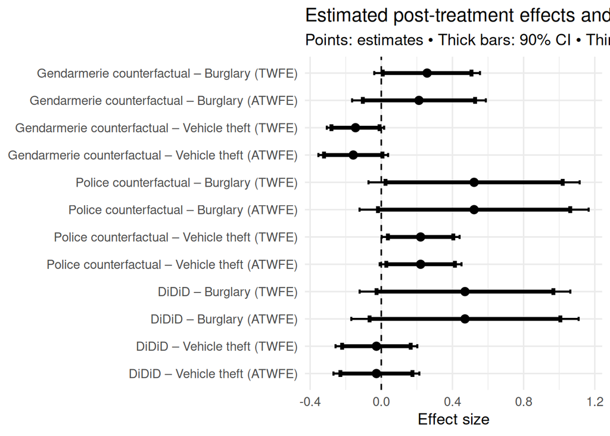

```r
model_order <- c(
  "cg_burglary2",
  "cg_burglary4",
  "cg_vehicle_theft2",
  "cg_vehicle_theft4",
  "gp_burglary2",
  "gp_burglary4",
  "gp_vehicle_theft2",
  "gp_vehicle_theft4",
  "cd3_burglary2",
  "cd3_burglary4",
  "cd3_vehicle_theft2",
  "cd3_vehicle_theft4"
  )


# right names for models

model_labels <- c(
  cg_burglary2        = "Gendarmerie counterfactual – Burglary (TWFE)",
  cg_burglary4        = "Gendarmerie counterfactual – Burglary (ATWFE)",
  cg_vehicle_theft2  = "Gendarmerie counterfactual – Vehicle theft (TWFE)",
  cg_vehicle_theft4  = "Gendarmerie counterfactual – Vehicle theft (ATWFE)",
  gp_burglary2       = "Police counterfactual – Burglary (TWFE)",
  gp_burglary4       = "Police counterfactual – Burglary (ATWFE)",
  gp_vehicle_theft2  = "Police counterfactual – Vehicle theft (TWFE)",
  gp_vehicle_theft4  = "Police counterfactual – Vehicle theft (ATWFE)",
  cd3_burglary2      = "DiDiD – Burglary (TWFE)",
  cd3_burglary4      = "DiDiD – Burglary (ATWFE)",
  cd3_vehicle_theft2 = "DiDiD – Vehicle theft (TWFE)",
  cd3_vehicle_theft4 = "DiDiD – Vehicle theft (ATWFE)"
)

results_table_pp <- results_table_pp %>%
  mutate(
    model = factor(
      model,
      levels = model_order,
      labels = model_labels[model_order]
    )
  )


# plot

ggplot(results_table_pp,
       aes(y = as.factor(model), x = estimate)) +

  # --- 95% CI (thin) ---
  geom_errorbarh(
    aes(xmin = ci95_low, xmax = ci95_high),
    height = 0.15,
    linewidth = 0.8
  ) +

  # --- 90% CI (thick) ---
  geom_errorbarh(
    aes(xmin = ci90_low, xmax = ci90_high),
    height = 0.25,
    linewidth = 1.5
  ) +

  # --- Point estimate ---
  geom_point(size = 2.8) +

  # --- Zero line ---
  geom_vline(xintercept = 0, linetype = "dashed") +

  labs(
    x = "Effect size",
    y = NULL,
    title = "Estimated post-treatment effects and detectability",
    subtitle = "Points: estimates • Thick bars: 90% CI • Thin bars: 95% CI"
  ) +
   scale_y_discrete(limits = rev) +

  theme_minimal(base_size = 13)
```

```r
ggsave("../output/recap_model4.pdf", width = 3600, height = 2400, units = "px")

#
```

## Placebo and randomization

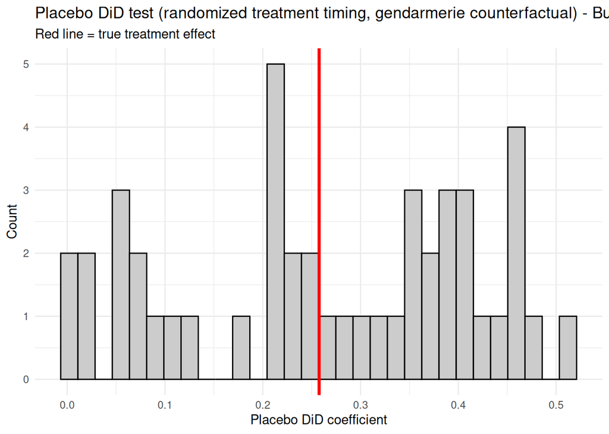

```r
# Candidate placebo dates (monthly)
placebo_dates <- seq(
  as.Date("2015-02-01"),
  as.Date("2018-11-01"),
  by = "month"
)

true_treat_date <- as.Date("2017-10-01")

# gendarmerie

run_placebo_did_burglary <- function(df, placebo_date) {

  df <- df %>%
    mutate(post_placebo = as.integer(date >= placebo_date))

  m_burglary <- feols(
    burglary_r ~ post_placebo + treat + dep_n + post_placebo:treat + dep_n:post_placebo |
      jurisdiction_department + date + department_month,
    data = df,
    cluster = "jurisdiction_department"
  )

  coef(m_burglary)["post_placebo:treat"]
}

run_placebo_did_vehicle_theft <- function(df, placebo_date) {

  df <- df %>%
    mutate(post_placebo = as.integer(date >= placebo_date))

  m_vehicle_theft <- feols(
    vehicle_theft_r ~ post_placebo + treat + dep_n + post_placebo:treat + dep_n:post_placebo |
      jurisdiction_department + date + department_month,
    data = df,
    cluster = "jurisdiction_department"
  )

  coef(m_vehicle_theft)["post_placebo:treat"]
}

# police

run_placebo_did_police_burglary <- function(df, placebo_date) {

  df <- df %>%
    mutate(post_placebo = as.integer(date >= placebo_date))

  m_burglary <- feols(
    burglary_r ~ post_placebo + jurisdiction + post_placebo:jurisdiction |
      jurisdiction_department + date + department_month,
    data = df,
    cluster = "jurisdiction_department"
  )

  coef(m_burglary)["post_placebo:jurisdictiongn"]
}

#

run_placebo_did_police_vehicle_theft <- function(df, placebo_date) {

  df <- df %>%
    mutate(post_placebo = as.integer(date >= placebo_date))

  m_vehicle_theft <- feols(
    vehicle_theft_r ~ post_placebo + jurisdiction + post_placebo:jurisdiction |
      jurisdiction_department + date + department_month,
    data = df,
    cluster = "jurisdiction_department"
  )

  coef(m_vehicle_theft)["post_placebo:jurisdictiongn"]
}

# didid

run_placebo_didid_burglary <- function(df, placebo_date) {

  df <- df %>%
    mutate(post_placebo = as.integer(date >= placebo_date))

  m_burglary <- feols(
    burglary_r ~ post_placebo*dep_w*jurisdiction + post_placebo*dep_n | jurisdiction_department + date + department_month,
    data = df,
    cluster = "jurisdiction_department"
  )

  coef(m_burglary)["post_placebo:dep_w:jurisdictiongn"]
}


run_placebo_didid_vehicle_theft <- function(df, placebo_date) {

  df <- df %>%
    mutate(post_placebo = as.integer(date >= placebo_date))

  m_vehicle_theft <- feols(
    vehicle_theft_r ~ post_placebo*dep_w*jurisdiction + post_placebo*dep_n | jurisdiction_department + date + department_month,
    data = df,
    cluster = "jurisdiction_department"
  )

  coef(m_vehicle_theft)["post_placebo:dep_w:jurisdictiongn"]
}


# Run the regression using the functions : gendarmerie

placebo_coefs_burglary_cg <- sapply(placebo_dates, function(d) {
  run_placebo_did_burglary(df_gendarmerie, d)
})


placebo_coefs_vehicle_theft_cg <- sapply(placebo_dates, function(d) {
  run_placebo_did_vehicle_theft(df_gendarmerie, d)
})


placebo_df_burglary_cg <- data.frame(
  placebo_date = placebo_dates,
  coef = placebo_coefs_burglary_cg
)


placebo_df_vehicle_theft_cg <- data.frame(
  placebo_date = placebo_dates,
  coef = placebo_coefs_vehicle_theft_cg
)

# Run the regression using the functions : police

placebo_coefs_burglary_cp <- sapply(placebo_dates, function(d) {
  run_placebo_did_police_burglary(df_gendarmerie_police, d)
})


placebo_coefs_vehicle_theft_cp <- sapply(placebo_dates, function(d) {
  run_placebo_did_police_vehicle_theft(df_gendarmerie_police, d)
})


placebo_df_burglary_cp <- data.frame(
  placebo_date = placebo_dates,
  coef = placebo_coefs_burglary_cp
)


placebo_df_vehicle_theft_cp <- data.frame(
  placebo_date = placebo_dates,
  coef = placebo_coefs_vehicle_theft_cp
)

# Run the regression using the functions : didid

placebo_coefs_burglary_3d <- sapply(placebo_dates, function(d) {
  run_placebo_didid_burglary(df_didid, d)
})


placebo_coefs_vehicle_theft_3d <- sapply(placebo_dates, function(d) {
  run_placebo_didid_vehicle_theft(df_didid, d)
})


placebo_df_burglary_3d <- data.frame(
  placebo_date = placebo_dates,
  coef = placebo_coefs_burglary_3d
)


placebo_df_vehicle_theft_3d <- data.frame(
  placebo_date = placebo_dates,
  coef = placebo_coefs_vehicle_theft_3d
)



# True coeff for plots

true_coeff_burglary_cg <- coef(cg_burglary2)["post:treat"]
true_coeff_vehicle_theft_cg <- coef(cg_vehicle_theft2)["post:treat"]

true_coeff_burglary_cp <- coef(gp_burglary2)["post:jurisdictiongn"]
true_coeff_vehicle_theft_cp <- coef(gp_vehicle_theft2)["post:jurisdictiongn"]

true_coeff_burglary_3d <- coef(cd3_burglary2)["post:dep_w:jurisdictiongn"]
true_coeff_vehicle_theft_3d <- coef(cd3_vehicle_theft4)["post:dep_w:jurisdictiongn"]


# Plot: gendarmerie counterfactual

ggplot(placebo_df_burglary_cg, aes(x = abs(coef))) +
  geom_histogram(bins = 30, fill = "grey80", color = "black") +
  geom_vline(xintercept = abs(true_coeff_burglary_cg), color = "red", linewidth = 1.2) +
  labs(
    title = "Placebo DiD test (randomized treatment timing, gendarmerie counterfactual) - Burglary rate",
    subtitle = "Red line = true treatment effect",
    x = "Placebo DiD coefficient",
    y = "Count"
  ) +
  theme_minimal()
```

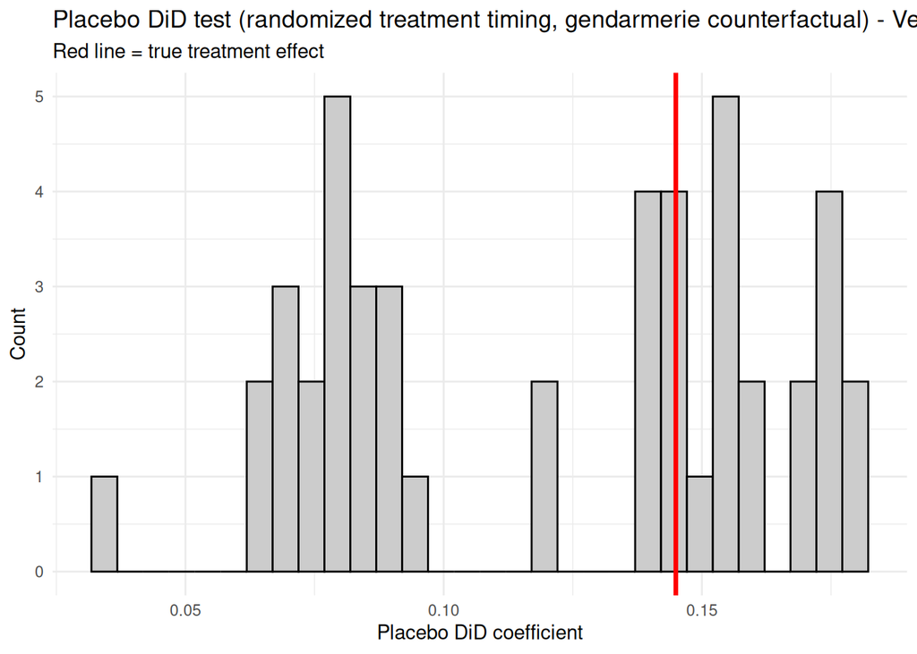

```r
ggsave("../output/placebo_counterfactual_gendarmerie_burglary_r.pdf", width = 2700, height = 1800, units = "px")



ggplot(placebo_df_vehicle_theft_cg, aes(x = abs(coef))) +
  geom_histogram(bins = 30, fill = "grey80", color = "black") +
  geom_vline(xintercept = abs(true_coeff_vehicle_theft_cg), color = "red", linewidth = 1.2) +
  labs(
    title = "Placebo DiD test (randomized treatment timing, gendarmerie counterfactual) - Vehicle theft rate",
    subtitle = "Red line = true treatment effect",
    x = "Placebo DiD coefficient",
    y = "Count"
  ) +
  theme_minimal()
```

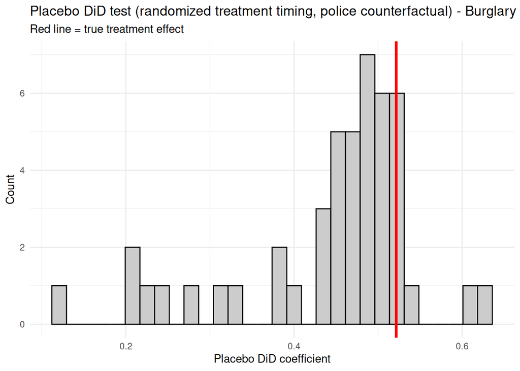

```r
ggsave("../output/placebo_counterfactual_gendarmerie_vehicle_theft_r.pdf", width = 2700, height = 1800, units = "px")


# Plot: police counterfactual

ggplot(placebo_df_burglary_cp, aes(x = abs(coef))) +
  geom_histogram(bins = 30, fill = "grey80", color = "black") +
  geom_vline(xintercept = abs(true_coeff_burglary_cp), color = "red", linewidth = 1.2) +
  labs(
    title = "Placebo DiD test (randomized treatment timing, police counterfactual) - Burglary rate",
    subtitle = "Red line = true treatment effect",
    x = "Placebo DiD coefficient",
    y = "Count"
  ) +
  theme_minimal()
```

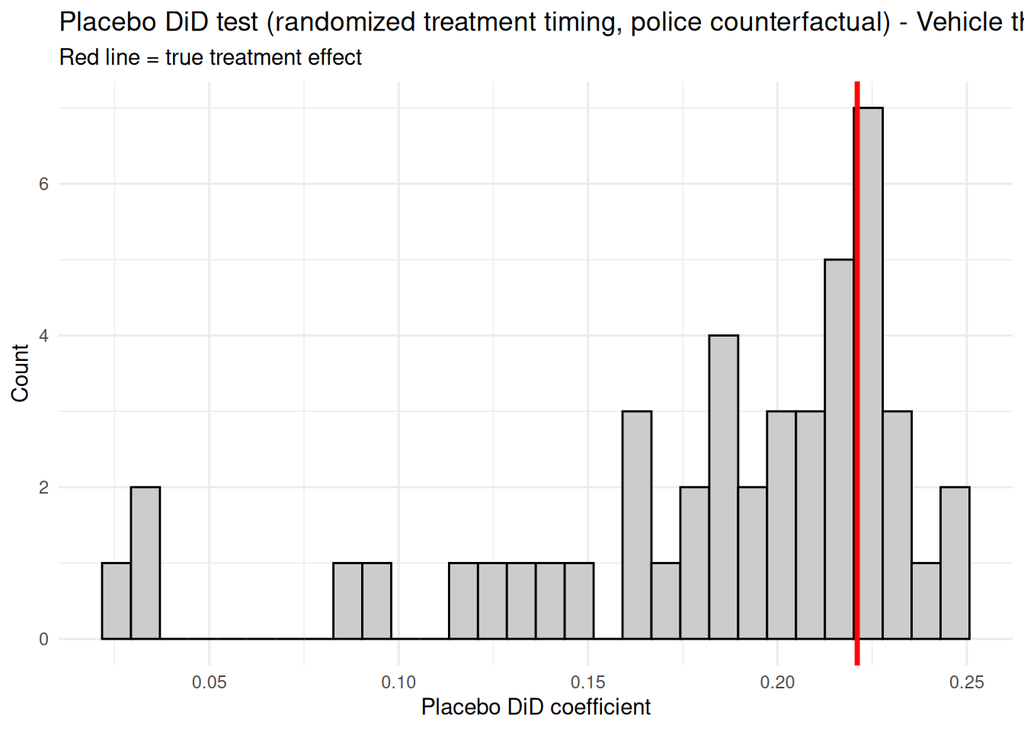

```r
ggsave("../output/placebo_counterfactual_police_burglary_r.pdf", width = 2700, height = 1800, units = "px")



ggplot(placebo_df_vehicle_theft_cp, aes(x = abs(coef))) +
  geom_histogram(bins = 30, fill = "grey80", color = "black") +
  geom_vline(xintercept = abs(true_coeff_vehicle_theft_cp), color = "red", linewidth = 1.2) +
  labs(
    title = "Placebo DiD test (randomized treatment timing, police counterfactual) - Vehicle theft rate",
    subtitle = "Red line = true treatment effect",
    x = "Placebo DiD coefficient",
    y = "Count"
  ) +
  theme_minimal()
```

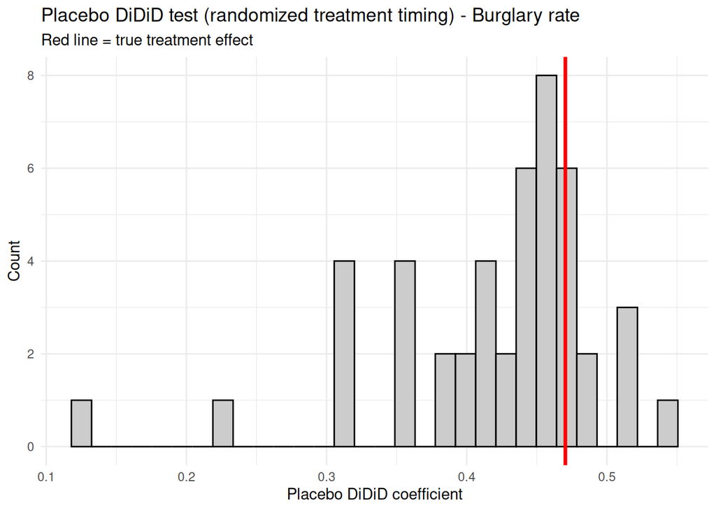

```r
ggsave("../output/placebo_counterfactual_police_vehicle_theft_r.pdf", width = 2700, height = 1800, units = "px")

# Plot: didid counterfactual

ggplot(placebo_df_burglary_3d, aes(x = abs(coef))) +
  geom_histogram(bins = 30, fill = "grey80", color = "black") +
  geom_vline(xintercept = abs(true_coeff_burglary_3d), color = "red", linewidth = 1.2) +
  labs(
    title = "Placebo DiDiD test (randomized treatment timing) - Burglary rate",
    subtitle = "Red line = true treatment effect",
    x = "Placebo DiDiD coefficient",
    y = "Count"
  ) +
  theme_minimal()
```

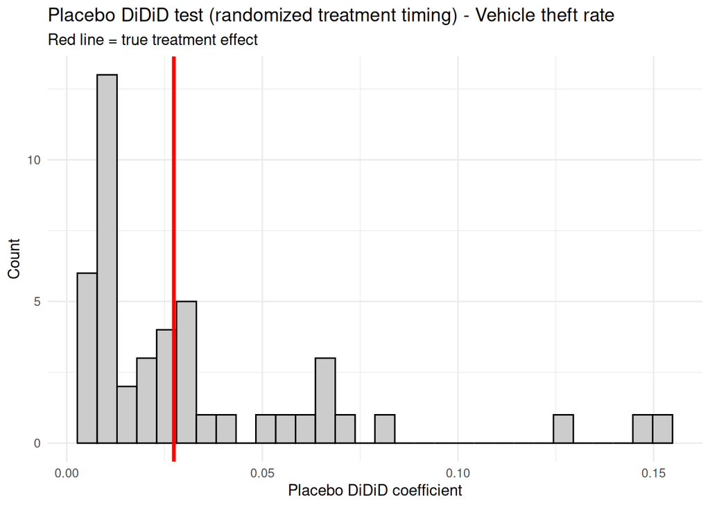

```r
ggsave("../output/placebo_counterfactual_3d_burglary_r.pdf", width = 2700, height = 1800, units = "px")



ggplot(placebo_df_vehicle_theft_3d, aes(x = abs(coef))) +
  geom_histogram(bins = 30, fill = "grey80", color = "black") +
  geom_vline(xintercept = abs(true_coeff_vehicle_theft_3d), color = "red", linewidth = 1.2) +
  labs(
    title = "Placebo DiDiD test (randomized treatment timing) - Vehicle theft rate",
    subtitle = "Red line = true treatment effect",
    x = "Placebo DiDiD coefficient",
    y = "Count"
  ) +
  theme_minimal()
```

```r
ggsave("../output/placebo_counterfactual_3d_vehicle_theft_r.pdf", width = 2700, height = 1800, units = "px")


# Distribution of average effect


mean(abs(placebo_df_burglary_cg$coef) >= abs(true_coeff_burglary_cg))
```

```
## [1] 0.5217391
```

```r
mean(abs(placebo_df_vehicle_theft_cg$coef) >= abs(true_coeff_vehicle_theft_cg))
```

```
## [1] 0.3913043
```

```r
mean(abs(placebo_df_burglary_cp$coef) >= abs(true_coeff_burglary_cp))
```

```
## [1] 0.1304348
```

```r
mean(abs(placebo_df_vehicle_theft_cp$coef) >= abs(true_coeff_vehicle_theft_cp))
```

```
## [1] 0.2608696
```

```r
mean(abs(placebo_df_burglary_3d$coef) >= abs(true_coeff_burglary_3d))
```

```
## [1] 0.2173913
```

```r
mean(abs(placebo_df_vehicle_theft_3d$coef) >= abs(true_coeff_vehicle_theft_3d))
```

```
## [1] 0.4347826
```

## Short and long term effect

The treatment period is divided in 3

```r
df_didid$jurisdiction <- as.factor(df_didid$jurisdiction)
df_didid$jurisdiction <- relevel(df_didid$jurisdiction, "pn")

df_gendarmerie_police$jurisdiction <- as.factor(df_gendarmerie_police$jurisdiction)

df_gendarmerie_police$jurisdiction <- relevel(df_gendarmerie_police$jurisdiction, "pn")

cg_burglary4_slterm <- feols(burglary_r ~ post_1_3 + treat + dep_n + post_1_3:treat + post_1_3:post | jurisdiction_department + date + department_month, df_gendarmerie, cluster = 'jurisdiction_department')

cg_vehicle_theft4_slterm <- feols(vehicle_theft_r ~ post_1_3 + treat + dep_n + post_1_3:treat + dep_n:post_1_3 | jurisdiction_department + date + department_month, df_gendarmerie, cluster = 'jurisdiction_department')

gp_burglary4_slterm <- feols(burglary_r ~ post_1_3 + jurisdiction + post_1_3:jurisdiction | jurisdiction_department + date + department_month, df_gendarmerie_police, cluster = 'jurisdiction_department')

gp_vehicle_theft4_slterm <- feols(vehicle_theft_r ~ post_1_3 + jurisdiction + post_1_3:jurisdiction | jurisdiction_department + date + department_month, df_gendarmerie_police, cluster = 'jurisdiction_department')

cd3_burglary4_slterm <- feols(burglary_r ~ post_1_3*dep_w*jurisdiction + post_1_3*dep_n | jurisdiction_department + date + department_month, df_didid, cluster = 'jurisdiction_department')

cd3_vehicle_theft4_slterm <- feols(vehicle_theft_r ~ post_1_3*dep_w*jurisdiction + post_1_3*dep_n | jurisdiction_department + date + department_month, df_didid, cluster = 'jurisdiction_department')

etable(cg_burglary4_slterm, cg_vehicle_theft4_slterm, gp_burglary4_slterm, gp_vehicle_theft4_slterm, cd3_burglary4_slterm, cd3_vehicle_theft4_slterm)
```

```
##                                    cg_burglary4_.. cg_vehicle_thef..
## Dependent Var.:                         burglary_r   vehicle_theft_r
##
## post_1_31 x treat                  0.4650 (0.3319) -0.1622. (0.0970)
## post_1_32 x treat                  0.0968 (0.1709)  -0.1262 (0.0924)
## post_1_33 x treat                  0.0656 (0.2176)  -0.1919 (0.1366)
## post_1_31 x dep_n                                   -0.0020 (0.0643)
## post_1_32 x dep_n                                   -0.0054 (0.0695)
## post_1_33 x dep_n                                   -0.0297 (0.0717)
## post_1_31 x jurisdictiongn
## post_1_32 x jurisdictiongn
## post_1_33 x jurisdictiongn
## post_1_31 x dep_w
## post_1_32 x dep_w
## post_1_33 x dep_w
## post_1_31 x dep_w x jurisdictiongn
## post_1_32 x dep_w x jurisdictiongn
## post_1_33 x dep_w x jurisdictiongn
## Fixed-Effects:                     --------------- -----------------
## jurisdiction_department                        Yes               Yes
## date                                           Yes               Yes
## department_month                               Yes               Yes
## __________________________________ _______________ _________________
## S.E.: Clustered                    by: jurisdict.. by: jurisdictio..
## Observations                                 4,416             4,416
## R2                                         0.75704           0.86934
## Within R2                                  0.00604           0.00678
##
##                                    gp_burglary4_.. gp_vehicle_the..
## Dependent Var.:                         burglary_r  vehicle_theft_r
##
## post_1_31 x treat
## post_1_32 x treat
## post_1_33 x treat
## post_1_31 x dep_n
## post_1_32 x dep_n
## post_1_33 x dep_n
## post_1_31 x jurisdictiongn         0.6027 (0.4069) 0.2170. (0.1176)
## post_1_32 x jurisdictiongn         0.3867 (0.3267)  0.2048 (0.1355)
## post_1_33 x jurisdictiongn         0.5754 (0.3613) 0.2414. (0.1303)
```

[output cut: 30 more lines]

```
## post_1_33 x dep_w                  -0.5778. (0.3469)   -0.1611 (0.1145)
## post_1_31 x dep_w x jurisdictiongn   0.4608 (0.4042)   -0.0806 (0.1241)
## post_1_32 x dep_w x jurisdictiongn   0.3902 (0.3270)    0.0649 (0.1443)
## post_1_33 x dep_w x jurisdictiongn   0.5602 (0.3650)   -0.0664 (0.1372)
## Fixed-Effects:                     ----------------- ------------------
## jurisdiction_department                          Yes                Yes
## date                                             Yes                Yes
## department_month                                 Yes                Yes
## __________________________________ _________________ __________________
## S.E.: Clustered                    by: jurisdictio.. by: jurisdiction..
## Observations                                   8,832              8,832
## R2                                           0.75451            0.86770
## Within R2                                    0.00675            0.01900
## ---
## Signif. codes: 0 '***' 0.001 '**' 0.01 '*' 0.05 '.' 0.1 ' ' 1
```

```r
file_path <- "../output/tables/short_long_term_effects.tex"
sink(file_path)
etable(cg_burglary4_slterm, cg_vehicle_theft4_slterm, gp_burglary4_slterm, gp_vehicle_theft4_slterm, cd3_burglary4_slterm, cd3_vehicle_theft4_slterm, tex = T)
sink()
```

## Long term plots

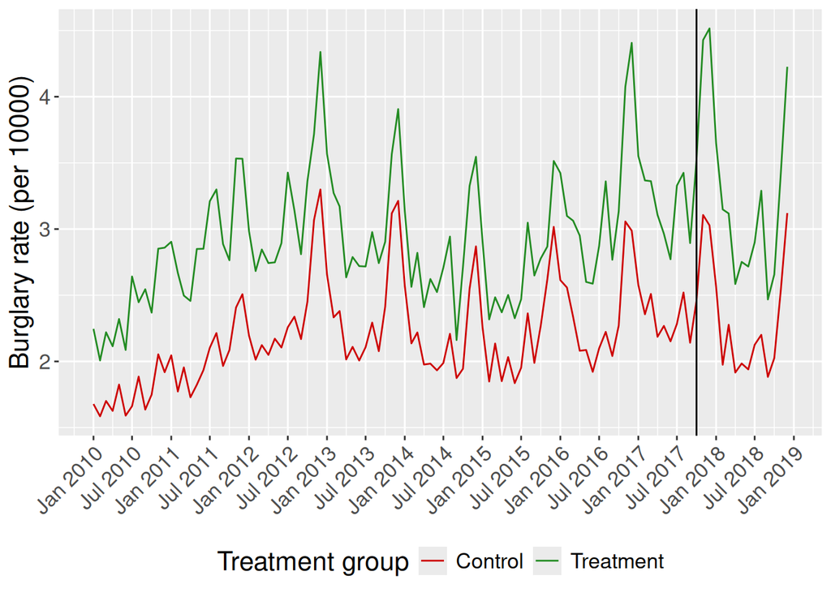

```r
# Gendarmerie counterfactual

ggplot(df_gendarmerie_plot, aes(y = burglary_r, x = date, color = factor(treat), group = factor(treat))) +
  stat_summary(fun = "mean", geom = "line") +
  geom_vline(xintercept = as.numeric(as.Date("2017-10-01"))) +
  scale_x_date(date_breaks = "6 month", date_labels =  "%b %Y") +
  theme(axis.text.x=element_text(angle=45, hjust=1), legend.position = "bottom", text = element_text(size = 16)) +
  labs(colour = "Treatment group", y = "Burglary rate (per 10000)", x = NULL) +
  scale_color_manual(values=c('red3','forestgreen'), labels=c("Control", "Treatment")) +
  scale_y_continuous()
```

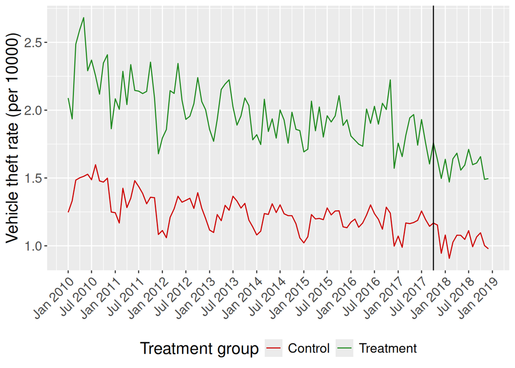

```r
ggsave("../output/long_term_counterfactual_gendarmerie_burglary_r.pdf", width = 2700, height = 1800, units = "px")


ggplot(df_gendarmerie_plot, aes(y = vehicle_theft_r, x = date, color = factor(dep_w), group = factor(dep_w))) +
  stat_summary(fun = "mean", geom = "line") +
  geom_vline(xintercept = as.numeric(as.Date("2017-10-01"))) +
  scale_x_date(date_breaks = "6 month", date_labels =  "%b %Y") +
  theme(axis.text.x=element_text(angle=45, hjust=1), legend.position = "bottom", text = element_text(size = 16)) +
  labs(colour = "Treatment group", y = "Vehicle theft rate (per 10000)", x = NULL) +
  scale_color_manual(values=c('red3','forestgreen'), labels=c("Control", "Treatment")) +
  scale_y_continuous()
```

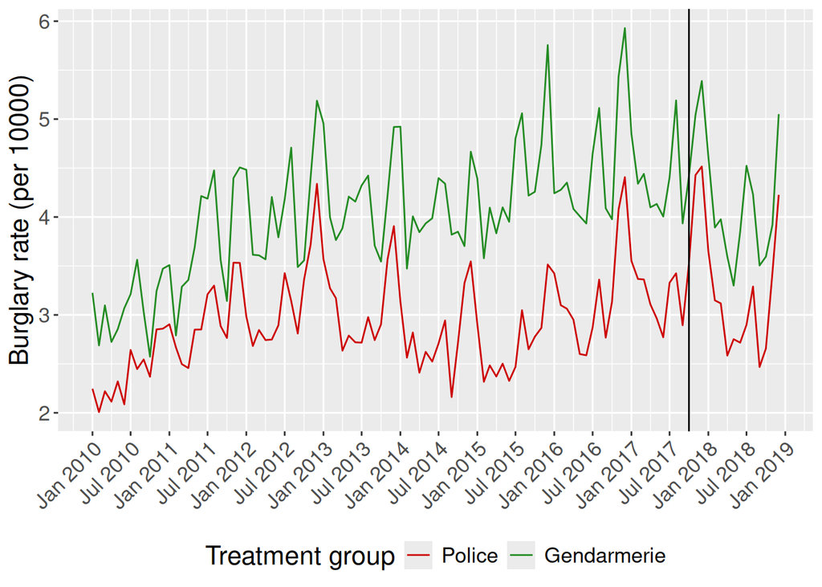

```r
ggsave("../output/long_term_counterfactual_gendarmerie_vehicle_theft_r.pdf", width = 2700, height = 1800, units = "px")

# Police counterfactual

ggplot(df_gendarmerie_police_plot, aes(y = burglary_r, x = date, color = factor(jurisdiction), group = factor(jurisdiction))) +
  stat_summary(fun = "mean", geom = "line") +
  geom_vline(xintercept = as.numeric(as.Date("2017-10-01"))) +
  scale_x_date(date_breaks = "6 month", date_labels =  "%b %Y") +
  theme(axis.text.x=element_text(angle=45, hjust=1), legend.position = "bottom", text = element_text(size = 16)) +
  labs(colour = "Treatment group", y = "Burglary rate (per 10000)", x = NULL) +
  scale_color_manual(values=c('red3', 'forestgreen'), labels = c("Police", "Gendarmerie")) +
  scale_y_continuous()
```

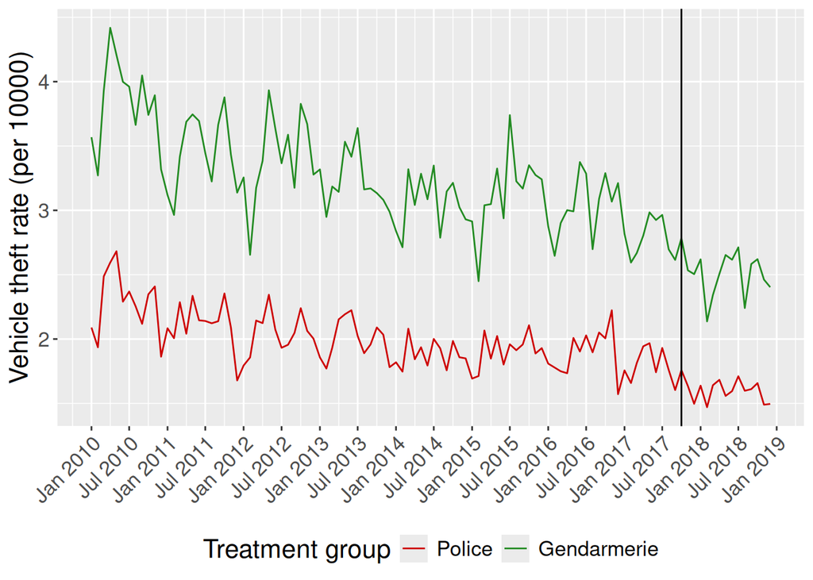

```r
ggsave("../output/long_term_counterfactual_police_burglary_r.pdf", width = 2700, height = 1800, units = "px")


ggplot(df_gendarmerie_police_plot, aes(y = vehicle_theft_r, x = date, color = factor(jurisdiction), group = factor(jurisdiction))) +
  stat_summary(fun = "mean", geom = "line") +
  geom_vline(xintercept = as.numeric(as.Date("2017-10-01"))) +
  scale_x_date(date_breaks = "6 month", date_labels =  "%b %Y") +
  theme(axis.text.x=element_text(angle=45, hjust=1), legend.position = "bottom", text = element_text(size = 16)) +
  labs(colour = "Treatment group", y = "Vehicle theft rate (per 10000)", x = NULL) +
  scale_color_manual(values=c('red3','forestgreen'), labels = c("Police", "Gendarmerie")) +
  scale_y_continuous()
```

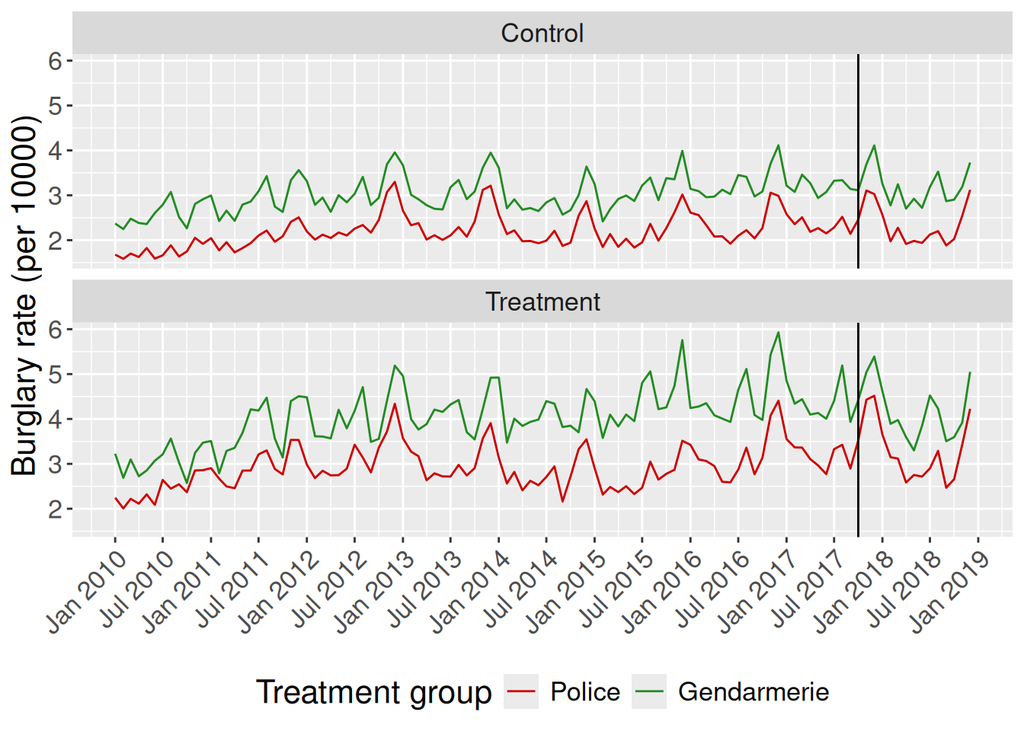

```r
ggsave("../output/long_term_counterfactual_police_vehicle_theft_r.pdf", width = 2700, height = 1800, units = "px")

## DiDiD


df_didid_plot$dep_w_plot <- ifelse(df_didid_plot$dep_w == 1, "Treatment", "Control")

ggplot(df_didid_plot, aes(y = burglary_r, x = date, color = factor(jurisdiction), group = factor(jurisdiction))) +
  stat_summary(fun = "mean", geom = "line") +
  geom_vline(xintercept = as.numeric(as.Date("2017-10-01"))) +
  scale_x_date(date_breaks = "6 month", date_labels =  "%b %Y") +
  theme(axis.text.x=element_text(angle=45, hjust=1), legend.position = "bottom", text = element_text(size = 16)) +
  labs(colour = "Treatment group", y = "Burglary rate (per 10000)", x = NULL) +
  scale_color_manual(values=c('red3', 'forestgreen'), labels = c("Police", "Gendarmerie")) +
  scale_y_continuous() +
  facet_wrap(~ dep_w_plot, ncol = 1)
```

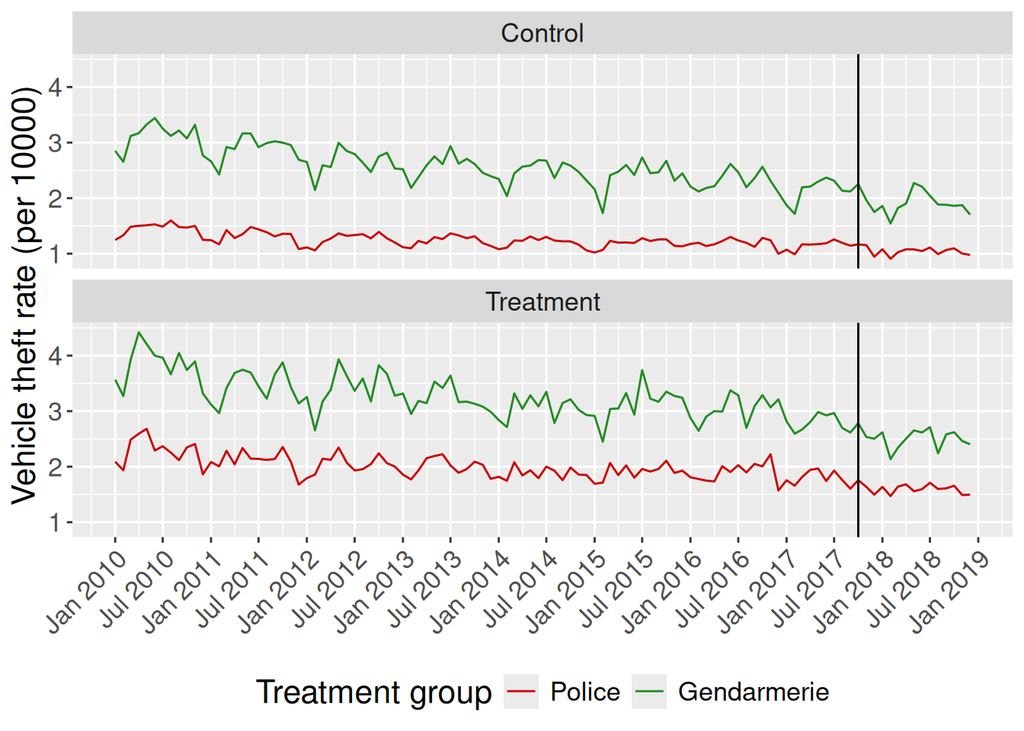

```r
ggsave("../output/long_term_counterfactual_didid_burglary_r.pdf", width = 2700, height = 2700, units = "px")

####

ggplot(df_didid_plot, aes(y = vehicle_theft_r, x = date, color = factor(jurisdiction), group = factor(jurisdiction))) +
  stat_summary(fun = "mean", geom = "line") +
  geom_vline(xintercept = as.numeric(as.Date("2017-10-01"))) +
  scale_x_date(date_breaks = "6 month", date_labels =  "%b %Y") +
  theme(axis.text.x=element_text(angle=45, hjust=1), legend.position = "bottom", text = element_text(size = 16)) +
  labs(colour = "Treatment group", y = "Vehicle theft rate (per 10000)", x = NULL) +
  scale_color_manual(values=c('red3', 'forestgreen'), labels = c("Police", "Gendarmerie")) +
  scale_y_continuous() +
  facet_wrap(~ dep_w_plot, ncol = 1)
```

```r
ggsave("../output/long_term_counterfactual_didid_vehicle_theft_r.pdf", width = 2700, height = 2700, units = "px")
```

## Honest DiD approach

Run in parallel

```r
library(doParallel)
registerDoParallel(cores = 10)
```

Burglary

```r
# Baseline model, event study

cg_burglary1_es <- feols(
  burglary_r ~  i(date, treat, ref = as.Date("2017-09-01")) | date + jurisdiction_department,
  data = subset(df_gendarmerie, dep_n == 0),
  cluster = ~ jurisdiction_department
)

gp_burglary1_es <- feols(burglary_r ~ i(date, jurisdiction_gn, ref = as.Date("2017-09-01")) | jurisdiction_department + date, df_gendarmerie_police, cluster = 'jurisdiction_department')

d3_burglary1_es <- feols(burglary_r ~ i(date, dep_w*jurisdiction_gn, ref = as.Date("2017-09-01")) | jurisdiction_department + date, df_didid, cluster = 'jurisdiction_department')


# Save coefficients
betahat_cg_burglary1_es <- summary(cg_burglary1_es)$coefficients
betahat_gp_burglary1_es <- summary(gp_burglary1_es)$coefficients
betahat_d3_burglary1_es <- summary(d3_burglary1_es)$coefficients

# Save the covariance matrix
sigma_cg_burglary1_es <- summary(cg_burglary1_es)$cov.scaled
sigma_gp_burglary1_es <- summary(gp_burglary1_es)$cov.scaled
sigma_d3_burglary1_es <- summary(d3_burglary1_es)$cov.scaled

#

delta_rm_results_cg_burglary1_es <- createSensitivityResults_relativeMagnitudes(
    betahat = betahat_cg_burglary1_es, #coefficients
    sigma = sigma_cg_burglary1_es, #covariance matrix
    numPrePeriods = 32, #num. of pre-treatment coefs
    numPostPeriods = 15, #num. of post-treatment coefs
    Mbarvec = seq(0.5,2,by=0.5), #values of Mbar
    parallel = TRUE
  )

delta_rm_results_gp_burglary1_es <- createSensitivityResults_relativeMagnitudes(
    betahat = betahat_gp_burglary1_es, #coefficients
    sigma = sigma_gp_burglary1_es, #covariance matrix
    numPrePeriods = 32, #num. of pre-treatment coefs
    numPostPeriods = 15, #num. of post-treatment coefs
    Mbarvec = seq(0.5,2,by=0.5), #values of Mbar
    parallel = TRUE
  )


delta_rm_results_d3_burglary1_es <- createSensitivityResults_relativeMagnitudes(
    betahat = betahat_d3_burglary1_es, #coefficients
    sigma = sigma_d3_burglary1_es, #covariance matrix
    numPrePeriods = 32, #num. of pre-treatment coefs
    numPostPeriods = 15, #num. of post-treatment coefs
    Mbarvec = seq(0.5,2,by=0.5), #values of Mbar
    parallel = TRUE
  )


delta_rm_results_cg_burglary1_es
```

```
## # A tibble: 4 × 5
##       lb    ub method Delta    Mbar
##    <dbl> <dbl> <chr>  <chr>   <dbl>
## 1 -0.528  1.20 C-LF   DeltaRM   0.5
## 2 -1.02   1.62 C-LF   DeltaRM   1
## 3 -1.55   2.15 C-LF   DeltaRM   1.5
## 4 -2.12   2.71 C-LF   DeltaRM   2
```

```r
delta_rm_results_gp_burglary1_es
```

```
## # A tibble: 4 × 5
##      lb    ub method Delta    Mbar
##   <dbl> <dbl> <chr>  <chr>   <dbl>
## 1 -1.18  1.73 C-LF   DeltaRM   0.5
## 2 -1.97  2.71 C-LF   DeltaRM   1
## 3 -2.90  3.70 C-LF   DeltaRM   1.5
## 4 -3.88  4.70 C-LF   DeltaRM   2
```

```r
delta_rm_results_d3_burglary1_es
```

```
## # A tibble: 4 × 5
##       lb    ub method Delta    Mbar
##    <dbl> <dbl> <chr>  <chr>   <dbl>
## 1 -0.278  1.34 C-LF   DeltaRM   0.5
## 2 -0.593  1.79 C-LF   DeltaRM   1
## 3 -0.939  2.26 C-LF   DeltaRM   1.5
## 4 -1.32   2.73 C-LF   DeltaRM   2
```

```r
# center the CI on the ATT for readability

delta_rm_results_cg_burglary1_es_corrected <- delta_rm_results_cg_burglary1_es %>%
  rowwise() %>%
  mutate(
    mid = (lb + ub) / 2,
    lb  = lb - mid + coef(cg_burglary2)["post:treat"],
    ub  = ub - mid + coef(cg_burglary2)["post:treat"]
  ) %>%
  ungroup() %>%
  select(-mid)

delta_rm_results_gp_burglary1_es_corrected <- delta_rm_results_gp_burglary1_es %>%
  rowwise() %>%
  mutate(
    mid = (lb + ub) / 2,
    lb  = lb - mid + coef(gp_burglary2)["post:jurisdictiongn"],
    ub  = ub - mid + coef(gp_burglary2)["post:jurisdictiongn"]
  ) %>%
  ungroup() %>%
  select(-mid)

delta_rm_results_d3_burglary1_es_corrected <- delta_rm_results_d3_burglary1_es %>%
  rowwise() %>%
  mutate(
    mid = (lb + ub) / 2,
    lb  = lb - mid + coef(cd3_burglary2)["post:dep_w:jurisdictiongn"],
    ub  = ub - mid + coef(cd3_burglary2)["post:dep_w:jurisdictiongn"]
  ) %>%
  ungroup() %>%
  select(-mid)

# Plot

originalResults_cg_burglary1_es <- tibble(
  lb     = coef(cg_burglary2)["post:treat"] - se(cg_burglary2)["post:treat"]*1.96,
  ub     = coef(cg_burglary2)["post:treat"] + se(cg_burglary2)["post:treat"]*1.96,
  method = "Original",
  Delta  = NA
)

originalResults_gp_burglary1_es <- tibble(
  lb     = coef(gp_burglary2)["post:jurisdictiongn"] - se(gp_burglary2)["post:jurisdictiongn"]*1.96,
  ub     = coef(gp_burglary2)["post:jurisdictiongn"] + se(gp_burglary2)["post:jurisdictiongn"]*1.96,
  method = "Original",
  Delta  = NA
)

originalResults_d3_burglary1_es <- tibble(
  lb     = coef(cd3_burglary2)["post:dep_w:jurisdictiongn"] - se(cd3_burglary2)["post:dep_w:jurisdictiongn"]*1.96,
  ub     = coef(cd3_burglary2)["post:dep_w:jurisdictiongn"] + se(cd3_burglary2)["post:dep_w:jurisdictiongn"]*1.96,
  method = "Original",
  Delta  = NA
)

#

pdf("../output/honest_did_cg_burglary.pdf")
createSensitivityPlot_relativeMagnitudes(delta_rm_results_cg_burglary1_es_corrected, originalResults_cg_burglary1_es)
dev.off()
```

```r
pdf("../output/honest_did_cp_burglary.pdf")
createSensitivityPlot_relativeMagnitudes(delta_rm_results_cg_burglary1_es_corrected, originalResults_gp_burglary1_es)
dev.off()
```

```r
pdf("../output/honest_did_3d_burglary.pdf")
createSensitivityPlot_relativeMagnitudes(delta_rm_results_d3_burglary1_es_corrected, originalResults_d3_burglary1_es)
dev.off()
```

Vehicle theft

```r
library(HonestDiD)

# Baseline model, event study

cg_vehicle_theft1_es <- feols(
  vehicle_theft_r ~  i(date, treat, ref = as.Date("2017-09-01")) | date + jurisdiction_department,
  data = subset(df_gendarmerie, dep_n == 0),
  cluster = ~ jurisdiction_department
)

gp_vehicle_theft1_es <- feols(vehicle_theft_r ~ i(date, jurisdiction_gn, ref = as.Date("2017-09-01")) | jurisdiction_department + date, df_gendarmerie_police, cluster = 'jurisdiction_department')

d3_vehicle_theft1_es <- feols(vehicle_theft_r ~ i(date, dep_w*jurisdiction_gn, ref = as.Date("2017-09-01")) | jurisdiction_department + date, df_didid, cluster = 'jurisdiction_department')


# Save coefficients
betahat_cg_vehicle_theft1_es <- summary(cg_vehicle_theft1_es)$coefficients
betahat_gp_vehicle_theft1_es <- summary(gp_vehicle_theft1_es)$coefficients
betahat_d3_vehicle_theft1_es <- summary(d3_vehicle_theft1_es)$coefficients

# Save the covariance matrix
sigma_cg_vehicle_theft1_es <- summary(cg_vehicle_theft1_es)$cov.scaled
sigma_gp_vehicle_theft1_es <- summary(gp_vehicle_theft1_es)$cov.scaled
sigma_d3_vehicle_theft1_es <- summary(d3_vehicle_theft1_es)$cov.scaled

#

delta_rm_results_cg_vehicle_theft1_es <- createSensitivityResults_relativeMagnitudes(
    betahat = betahat_cg_vehicle_theft1_es, #coefficients
    sigma = sigma_cg_vehicle_theft1_es, #covariance matrix
    numPrePeriods = 32, #num. of pre-treatment coefs
    numPostPeriods = 15, #num. of post-treatment coefs
    Mbarvec = seq(0.5,2,by=0.5), #values of Mbar
    parallel = TRUE
  )

delta_rm_results_gp_vehicle_theft1_es <- createSensitivityResults_relativeMagnitudes(
    betahat = betahat_gp_vehicle_theft1_es, #coefficients
    sigma = sigma_gp_vehicle_theft1_es, #covariance matrix
    numPrePeriods = 32, #num. of pre-treatment coefs
    numPostPeriods = 15, #num. of post-treatment coefs
    Mbarvec = seq(0.5,2,by=0.5), #values of Mbar
    parallel = TRUE
  )


delta_rm_results_d3_vehicle_theft1_es <- createSensitivityResults_relativeMagnitudes(
    betahat = betahat_d3_vehicle_theft1_es, #coefficients
    sigma = sigma_d3_vehicle_theft1_es, #covariance matrix
    numPrePeriods = 32, #num. of pre-treatment coefs
    numPostPeriods = 15, #num. of post-treatment coefs
    Mbarvec = seq(0.5,2,by=0.5), #values of Mbar
    parallel = TRUE
  )


delta_rm_results_cg_vehicle_theft1_es
```

```
## # A tibble: 4 × 5
##       lb    ub method Delta    Mbar
##    <dbl> <dbl> <chr>  <chr>   <dbl>
## 1 -0.194 0.701 C-LF   DeltaRM   0.5
## 2 -0.536 1.07  C-LF   DeltaRM   1
## 3 -0.909 1.45  C-LF   DeltaRM   1.5
## 4 -1.29  1.84  C-LF   DeltaRM   2
```

```r
delta_rm_results_gp_vehicle_theft1_es
```

```
## # A tibble: 4 × 5
##       lb    ub method Delta    Mbar
##    <dbl> <dbl> <chr>  <chr>   <dbl>
## 1 -0.667 0.768 C-LF   DeltaRM   0.5
## 2 -1.16  1.33  C-LF   DeltaRM   1
## 3 -1.69  1.91  C-LF   DeltaRM   1.5
## 4 -2.26  2.48  C-LF   DeltaRM   2
```

```r
delta_rm_results_d3_vehicle_theft1_es
```

```
## # A tibble: 4 × 5
##       lb    ub method Delta    Mbar
##    <dbl> <dbl> <chr>  <chr>   <dbl>
## 1 -0.288 0.554 C-LF   DeltaRM   0.5
## 2 -0.620 0.914 C-LF   DeltaRM   1
## 3 -0.983 1.28  C-LF   DeltaRM   1.5
## 4 -1.35  1.65  C-LF   DeltaRM   2
```

```r
# correct the centering

delta_rm_results_cg_vehicle_theft1_es_corrected <- delta_rm_results_cg_vehicle_theft1_es %>%
  rowwise() %>%
  mutate(
    mid = (lb + ub) / 2,
    lb  = lb - mid + coef(cg_vehicle_theft2)["post:treat"],
    ub  = ub - mid + coef(cg_vehicle_theft2)["post:treat"]
  ) %>%
  ungroup() %>%
  select(-mid)

delta_rm_results_gp_vehicle_theft1_es_corrected <- delta_rm_results_gp_vehicle_theft1_es %>%
  rowwise() %>%
  mutate(
    mid = (lb + ub) / 2,
    lb  = lb - mid + coef(gp_vehicle_theft2)["post:jurisdictiongn"],
    ub  = ub - mid + coef(gp_vehicle_theft2)["post:jurisdictiongn"]
  ) %>%
  ungroup() %>%
  select(-mid)


delta_rm_results_d3_vehicle_theft1_es_corrected <- delta_rm_results_d3_vehicle_theft1_es %>%
  rowwise() %>%
  mutate(
    mid = (lb + ub) / 2,
    lb  = lb - mid + coef(cd3_vehicle_theft2)["post:dep_w:jurisdictiongn"],
    ub  = ub - mid + coef(cd3_vehicle_theft2)["post:dep_w:jurisdictiongn"]
  ) %>%
  ungroup() %>%
  select(-mid)

# Plot


originalResults_cg_vehicle_theft1_es <- tibble(
  lb     = coef(cg_vehicle_theft2)["post:treat"] - se(cg_vehicle_theft2)["post:treat"]*1.96,
  ub     = coef(cg_vehicle_theft2)["post:treat"] + se(cg_vehicle_theft2)["post:treat"]*1.96,
  method = "Original",
  Delta  = NA
)

originalResults_gp_vehicle_theft1_es <- tibble(
  lb     = coef(gp_vehicle_theft2)["post:jurisdictiongn"] - se(gp_vehicle_theft2)["post:jurisdictiongn"]*1.96,
  ub     = coef(gp_vehicle_theft2)["post:jurisdictiongn"] + se(gp_vehicle_theft2)["post:jurisdictiongn"]*1.96,
  method = "Original",
  Delta  = NA
)

originalResults_d3_vehicle_theft1_es <- tibble(
  lb     = coef(cd3_vehicle_theft2)["post:dep_w:jurisdictiongn"] - se(cd3_vehicle_theft2)["post:dep_w:jurisdictiongn"]*1.96,
  ub     = coef(cd3_vehicle_theft2)["post:dep_w:jurisdictiongn"] + se(cd3_vehicle_theft2)["post:dep_w:jurisdictiongn"]*1.96,
  method = "Original",
  Delta  = NA
)

# assign the original standard error

pdf("../output/honest_did_cg_vehicle_theft.pdf")
createSensitivityPlot_relativeMagnitudes(delta_rm_results_cg_vehicle_theft1_es_corrected, originalResults_cg_vehicle_theft1_es)
dev.off()
```

```r
pdf("../output/honest_did_cp_vehicle_theft.pdf")
createSensitivityPlot_relativeMagnitudes(delta_rm_results_gp_vehicle_theft1_es_corrected, originalResults_gp_vehicle_theft1_es)
dev.off()
```

```r
pdf("../output/honest_did_3d_vehicle_theft.pdf")
createSensitivityPlot_relativeMagnitudes(delta_rm_results_d3_vehicle_theft1_es_corrected, originalResults_d3_vehicle_theft1_es)
dev.off()
```